# Macho-Nice Guy Dichotomy

Author

Gilad Sarusi

# 1 HistWords repo

For our purposes, I use the same approach chosen by Tessa E. S. Charlesworth and colleagues—namely, the HistWords repository, which is available on [GitHub](https://github.com/williamleif/histwords?tab=readme-ov-file).

### 1.0.1 What’s going on?

HistWords is an open-source dataset and toolkit that provides word embeddings for different historical periods, trained on Google Books Ngram (and other corpora). Each decade (1800–1990) has its own 300-dimensional vector space representing the meaning of words in that era.

Think of it as a longitudinal semantic dataset—rather than tracking people over time, we track words across decades. Each vector encodes a word’s position in the shared “meaning space” of its time.

#### 1.0.1.1 What can we do with it?

- **Inspect meaning:** find the nearest neighbors of a word in any decade.
- **Compare meanings over time:** compute cosine similarity for the same word across decades to track semantic drift.
- **Study cultural change:** analyze how a word’s associations (e.g., *macho*, *nice*) evolve by decade.
- **Compose phrases:** average vectors (e.g., *macho* + *guy*) to represent multi-word concepts.
- **Align embeddings:** apply sequential Procrustes alignment to make spaces from different decades comparable.

### 1.0.2 What are we comparing?

In this project, I adopt an approach similar to Tessa et al. designed to avoid the **alignment problem** inherent in diachronic word embeddings—which makes direct comparison of raw cosine similarities between two embedding spaces (e.g., the 1910s and the 1920s) invalid.

Instead of comparing one decade directly with another, I compare words **within each decade**. In other words, for every decade I ask a simple question: is a given word closer to the *Macho* prototype or to the *Nice Guy* prototype?

To do this, the code builds a vector for each prototype in each decade and then gives every word a **single contrast score**. Positive scores mean the word is closer to the Macho side; negative scores mean it is closer to the Nice side. This lets me describe change across time without pretending that the raw geometry of one decade can be directly compared with the raw geometry of another.

More concretely, the current script does four things:

1. it builds decade-specific *Macho* and *Nice Guy* vectors in two different ways: a **nudge** version and an **inject** version;
2. it uses an anchored scoring method to estimate where each word falls on the Macho-versus-Nice contrast within that decade;
3. it scores every usable ENGall word for the lexicon-wide baseline, while attaching Warriner ratings only to the subset used in affect-based analyses; and
4. in the Attractiveness section, it compares two scoring workflows side by side: the original pairwise cosine approach and the newer anchored approach.

Nevertheless, following Tessa et al.’s guidance, applying **orthogonal Procrustes** rotation can still be useful as a robustness check or for future extensions involving cross-decade word-trajectory analyses.

`The following code is written using the ds4psych: Data Science for Psychology: Natural Language workflow (https://ds4psych.com). Therefore, the toolset used here differs from Tessa’s.`

# 2 Start

```r
apa_num <- function(x, digits = 2) {
  ifelse(
    is.na(x),
    NA_character_,
    sprintf(paste0("%.", digits, "f"), x)
  )
}

apa_p <- function(p) {
  case_when(
    is.na(p) ~ NA_character_,
    p < 0.001 ~ "< .001",
    TRUE ~ sub("^0\\.", ".", sprintf("%.3f", round(p, 3)))
  )
}

apa_ci <- function(low, high, digits = 2) {
  ifelse(
    is.na(low) | is.na(high),
    NA_character_,
    paste0(
      "[",
      sprintf(paste0("%.", digits, "f"), low),
      ", ",
      sprintf(paste0("%.", digits, "f"), high),
      "]"
    )
  )
}
```

Notably, in the 2000s there was a change in N-gram sampling. Therefore, embeddings using the corpus from the 2000s onward are excluded.

```r
## Words norm - for valence computation:


warriner_path <- "wordstim/allwrdnorms_warriner.csv"
# columns: word, valence, arousal, dominance - valence is the average rating on a 9-point scale from 1 (very negative) to 9 (very positive), obtained from Warriner and colleagues (2013)

# Theoretically we need to cosider that the fact that this was a crowdslabeling procedure taken place in 2013, the chatechristics of each trait in term of valence, arousal and dominance are reflecting the meaning of the word in 2013, which might be different from the meaning of the word in 1800. However, since we are interested in the relative valence of traits (e.g., is "kind" more positive than "dominant"?), and since these relative valence ratings are likely to be more stable over time than absolute ratings, I will proceed with using Warriner's ratings as a proxy for trait valence across all decades. This is a common approach in historical semantics research, although it is important to acknowledge this limitation when interpreting results.
```

As an alternative, we might consider NRC VAD (S. M. Mohammad, 2018), which contains 20,007 words with ratings between 0 and 1 for valence, arousal, and dominance.

### 2.0.1 Men Types Word List

```r
## List of traits:

traits_path <- "wordstim/traitlist.txt"

# We would latter on create a file storing those words for the code to be more elegant :

nice_guy_words <- c(
  "kind", "gentle", "caring", "sensitive", "considerate", "respectful",
  "supportive", "understanding", "warm", "affectionate",
  "polite", "reliable", "faithful", "honest", "thoughtful",
  "attentive", "humble", "nice"
)
macho_guy_words <- c(
   "dominant", "assertive", "confident", "tough", "strong", "decisive",
  "bold", "powerful", "competitive", "aggressive",  "unemotional",
  "fearless","alpha", "commanding", "ambitious", "macho"
)
```

### 2.0.2 Two ways of defining the constructs

To make sure these trait lists are interpreted in a masculine context, I use two slightly different strategies.

The first is to **inject male anchors**. This means I add words such as *man*, *men*, *male*, and *guy* to each list before averaging the embeddings. The goal is to pull the resulting vector toward a masculine semantic context rather than a generic trait context. This is implemented in the *Concepts* chunk.

- **Cons / watch-outs:**  
  *Anchor dominance risk*—male anchors can outweigh trait terms if the lists are small. Moreover, shared anchors in both groups reduce the distance between group centroids (smaller margins).  
  **Monitor:** anchor share in each centroid (≤30–40%), cosine margin between group means, and Top-N stability across decades (overlap %).

The second approach, implemented in the next chunk, is a **masculinity projection nudge**. Here I build a male-versus-female direction in the embedding space and then shift each construct slightly toward the male side before scoring it. This is a softer adjustment than injection: instead of adding anchor words into the list itself, it gently pushes the final vector toward a masculine interpretation.

- **Cons / watch-outs:**  
  *Axis quality*—if the gender sets are unbalanced or drift strongly by decade, the direction can be noisy.  
  *Leakage*—over-weighting (large *w*) can wash out original semantics.  
  **Monitor:** axis stability across decades (cosine between decade-specific *d*<sub>male</sub>), use small *w* (e.g., 0.1–0.3) and run sensitivity analyses; compare results with and without the tweak.

Using both approaches gives me a built-in robustness check. If the results tell the same story under both methods, that makes the interpretation more convincing.

### 2.0.3 Masculinity projection nudge

To interpret these trait bundles as referring to men rather than to personality in general, I create a female-to-male direction in the semantic space and add part of that direction to the construct vector. In plain language, this step nudges the vector so that later comparisons are more likely to reflect the masculine reading of the traits.

```r
# E: numeric matrix (rows = tokens, cols = dims),

# male_tokens / female_tokens: anchors for the axis (can leave defaults)

 male_anchors <-  c("man","men","male","guy")  #Question: should we add 'boy'?
 female_anchors <-  c("woman", "women", "female","girl")

 build_ddr <- function(embeddings, words) {
  available_words <- words[words %in% rownames(embeddings)]

  if (length(available_words) == 0) {
    stop("No construct words are available in this decade's embedding space.")
  }

  predict(embeddings, available_words) |>
    average_embedding()
}


 build_male_female_axis <- function(embeddings) {
  male_ddr <- build_ddr(embeddings, male_anchors)
  female_ddr <- build_ddr(embeddings, female_anchors)
  male_ddr - female_ddr
}



# DDR-based masculinity function:

# w = nudge strength (0 = no nudge, >0 = push toward masculine direction)

# default is set to 1 to inteperate results easily and to make sure that the wors be are assigning is regards to word_GUY not that word in general


masculinity_nudge <- function(ddr_vec, # Or any dim1:dim300 embedding object
                              E, # The embedding space
                              w = 1) {
 axis <- build_male_female_axis(E)
  axis <- as.numeric(axis)

  if (is.matrix(ddr_vec)) {

    ddr_vec_nudged <- sweep(
      ddr_vec,
      2,
      w * axis,
      FUN = "+"
    )

  } else {

    ddr_vec <- as.numeric(ddr_vec)
    ddr_vec_nudged <- ddr_vec + w * axis

  }

  ddr_vec_nudged

}
```

The second approach, the **Inject approach**, does the same job more directly: it adds male anchor words to each word list before averaging, so the resulting construct vector is explicitly tied to a masculine context.

### 2.0.4 ENGall Model

Properties of ENGall_model:

- n of words: 100,000 (same word list across all decades). the authors only computed embeddings for words that were among the top 100,000 most frequent words over all time (for EngAll)
  - n of dimensions: 300.
  - Type of Embedding : SGNS.
  - Context Window : symmetric context window of 4 words.

```r
## ----------- ENGall model -----------

if (file.exists("engall/ENGall_model.RDS")) {
  ENGall_model<-readRDS("engall/ENGall_model.RDS")
}else {
  ENGall_model <- lapply(model_names, load_embeddings, save = FALSE) # list of embedding models
  saveRDS(ENGall_model,
          file="engall/ENGall_model.RDS")
}
length(ENGall_model)
```

```
[1] 20
```

The ENGall model provides embeddings for the 100,000 most frequent words **across** all time. This means words coined later in history will be missing in earlier slices, and some words will be absent in particular decade models. The model is stored as a list of 20 elements, one per decade. In some decade data frames, certain words have no embedding.

let’s map those words.

```r
#### ---- Check unavailable words by decade ----
n_avwords <- vector()
n_unav<- vector()
prop_avail <- vector()
n_total <- vector()

# Creating a list of available word and unavailable words:

for (i in seq_along(ENGall_model)) {
  # Count available words as those with V1 != 0
  n_avwords[i] <- sum(ENGall_model[[i]][, 1] != 0)
  n_total[i] <- ENGall_model[[i]]|>
      nrow()
  n_unav[i]  <- n_total[i] - n_avwords[i]
  prop_avail[i] <- n_avwords[i] / n_total[i]
}


avwords_n_decade_df <- data.frame(
  decade      = decades,
  n_avwords   = n_avwords,
  n_unavwords = n_unav,
  prop_avail  = prop_avail
)
```

```r
kable(avwords_n_decade_df |>
        #adding comma
        mutate(across(where(is.numeric),scales::comma)),
      digits = 3,
      caption = "Proportion of Words with Embedding")
```

Proportion of Words with Embedding

| decade | n_avwords | n_unavwords | prop_avail |
| --- | --- | --- | --- |
| 1,800 | 13,045 | 86,955 | 0.1304 |
| 1,810 | 15,771 | 84,229 | 0.1577 |
| 1,820 | 20,312 | 79,688 | 0.2031 |
| 1,830 | 21,691 | 78,309 | 0.2169 |
| 1,840 | 23,818 | 76,182 | 0.2382 |
| 1,850 | 29,035 | 70,965 | 0.2904 |
| 1,860 | 27,191 | 72,809 | 0.2719 |
| 1,870 | 29,320 | 70,680 | 0.2932 |
| 1,880 | 34,081 | 65,919 | 0.3408 |
| 1,890 | 37,729 | 62,271 | 0.3773 |
| 1,900 | 41,551 | 58,449 | 0.4155 |
| 1,910 | 36,553 | 63,447 | 0.3655 |
| 1,920 | 35,643 | 64,357 | 0.3564 |
| 1,930 | 34,477 | 65,523 | 0.3448 |
| 1,940 | 34,226 | 65,774 | 0.3423 |
| 1,950 | 41,807 | 58,193 | 0.4181 |
| 1,960 | 54,332 | 45,668 | 0.5433 |
| 1,970 | 60,344 | 39,656 | 0.6034 |
| 1,980 | 64,934 | 35,066 | 0.6493 |
| 1,990 | 71,097 | 28,903 | 0.7110 |

Out of 100,000 words, each decade has on average 36,347 available words.

Notably, the 1990s slice has ~71% of words available. This does **not** mean “29% are post-1990 words.” Rather, 29% of the top-100k (over 1800–1999) simply lack enough occurrences in the 1990s to train vectors—often because they are earlier-era words that faded out, or because they are rare or orthographically different in that decade.

Later, we will pull valence from Warriner’s list (~14,000 words), which bounds our effective vocabulary to those items. Because not all Warriner words appear in ENGall, the intersection may be smaller.

Another concern is whether some of the words used to define our constructs are missing from the model.

Let’s check!

```r
### ---- Check if macho/nice words by decade -------
# 1) Availability (token x decade)

avail <- map2_df(ENGall_model, decades, ~
  tibble(
    decade    = .y,
    token     = tolower(rownames(.x)),
    available = .x[, 1] != 0
  )
)

#  Define the sets you care about
sets <- list(
  macho = macho_guy_words,
  nice  = nice_guy_words,
  male = male_anchors
)

wanted <- enframe(sets, name = "set", value = "token") |>
  unnest(token) |>
  mutate(token = tolower(token))

# proportion per decade + list of missing words
macho_nice_words_by_decade_df <- wanted |>
  left_join(avail, by = "token") |>
  mutate(available = tidyr::replace_na(available, FALSE)) |>
  group_by(set, decade) |>
  summarise(
    n_of_words_examined = n(),
    n_available = sum(available),
    prop_avail    = n_available / n_of_words_examined,
    missing     = list(token[!available]),
    .groups = "drop"
  ) |>
  arrange(set, decade)
```

```r
kable(macho_nice_words_by_decade_df,
      caption= "Construct's word presence across time")
```

Construct’s word presence across time

| set | decade | n_of_words_examined | n_available | prop_avail | missing |
| --- | --- | --- | --- | --- | --- |
| macho | 1800 | 16 | 8 | 0.5000000 | dominant , assertive , competitive, aggressive , unemotional, fearless , alpha , macho |
| macho | 1810 | 16 | 10 | 0.6250000 | dominant , assertive , competitive, aggressive , unemotional, macho |
| macho | 1820 | 16 | 10 | 0.6250000 | dominant , assertive , competitive, aggressive , unemotional, macho |
| macho | 1830 | 16 | 11 | 0.6875000 | assertive , competitive, aggressive , unemotional, macho |
| macho | 1840 | 16 | 11 | 0.6875000 | assertive , competitive, aggressive , unemotional, macho |
| macho | 1850 | 16 | 12 | 0.7500000 | assertive , competitive, unemotional, macho |
| macho | 1860 | 16 | 12 | 0.7500000 | assertive , competitive, unemotional, macho |
| macho | 1870 | 16 | 13 | 0.8125000 | assertive , unemotional, macho |
| macho | 1880 | 16 | 13 | 0.8125000 | assertive , unemotional, macho |
| macho | 1890 | 16 | 13 | 0.8125000 | assertive , unemotional, macho |
| macho | 1900 | 16 | 14 | 0.8750000 | unemotional, macho |
| macho | 1910 | 16 | 14 | 0.8750000 | unemotional, macho |
| macho | 1920 | 16 | 14 | 0.8750000 | unemotional, macho |
| macho | 1930 | 16 | 14 | 0.8750000 | unemotional, macho |
| macho | 1940 | 16 | 14 | 0.8750000 | unemotional, macho |
| macho | 1950 | 16 | 14 | 0.8750000 | unemotional, macho |
| macho | 1960 | 16 | 14 | 0.8750000 | unemotional, macho |
| macho | 1970 | 16 | 14 | 0.8750000 | unemotional, macho |
| macho | 1980 | 16 | 16 | 1.0000000 |  |
| macho | 1990 | 16 | 16 | 1.0000000 |  |
| male | 1800 | 4 | 4 | 1.0000000 |  |
| male | 1810 | 4 | 4 | 1.0000000 |  |
| male | 1820 | 4 | 4 | 1.0000000 |  |
| male | 1830 | 4 | 4 | 1.0000000 |  |
| male | 1840 | 4 | 4 | 1.0000000 |  |
| male | 1850 | 4 | 4 | 1.0000000 |  |
| male | 1860 | 4 | 4 | 1.0000000 |  |
| male | 1870 | 4 | 4 | 1.0000000 |  |
| male | 1880 | 4 | 4 | 1.0000000 |  |
| male | 1890 | 4 | 4 | 1.0000000 |  |
| male | 1900 | 4 | 4 | 1.0000000 |  |
| male | 1910 | 4 | 4 | 1.0000000 |  |
| male | 1920 | 4 | 4 | 1.0000000 |  |
| male | 1930 | 4 | 4 | 1.0000000 |  |
| male | 1940 | 4 | 4 | 1.0000000 |  |
| male | 1950 | 4 | 4 | 1.0000000 |  |
| male | 1960 | 4 | 4 | 1.0000000 |  |
| male | 1970 | 4 | 4 | 1.0000000 |  |
| male | 1980 | 4 | 4 | 1.0000000 |  |
| male | 1990 | 4 | 4 | 1.0000000 |  |
| nice | 1800 | 18 | 12 | 0.6666667 | caring , sensitive , considerate, supportive , reliable , thoughtful |
| nice | 1810 | 18 | 15 | 0.8333333 | caring , supportive, reliable |
| nice | 1820 | 18 | 16 | 0.8888889 | supportive, reliable |
| nice | 1830 | 18 | 16 | 0.8888889 | supportive, reliable |
| nice | 1840 | 18 | 17 | 0.9444444 | supportive |
| nice | 1850 | 18 | 17 | 0.9444444 | supportive |
| nice | 1860 | 18 | 17 | 0.9444444 | supportive |
| nice | 1870 | 18 | 17 | 0.9444444 | supportive |
| nice | 1880 | 18 | 17 | 0.9444444 | supportive |
| nice | 1890 | 18 | 17 | 0.9444444 | supportive |
| nice | 1900 | 18 | 17 | 0.9444444 | supportive |
| nice | 1910 | 18 | 17 | 0.9444444 | supportive |
| nice | 1920 | 18 | 17 | 0.9444444 | supportive |
| nice | 1930 | 18 | 17 | 0.9444444 | supportive |
| nice | 1940 | 18 | 17 | 0.9444444 | supportive |
| nice | 1950 | 18 | 18 | 1.0000000 |  |
| nice | 1960 | 18 | 18 | 1.0000000 |  |
| nice | 1970 | 18 | 18 | 1.0000000 |  |
| nice | 1980 | 18 | 18 | 1.0000000 |  |
| nice | 1990 | 18 | 18 | 1.0000000 |  |

It seems that many words in the Macho construct are missing from the corpus, although their availability remains relatively stable from around 1860 onward. For the Nice Guy construct, availability is more stable across time.To ensure that the results are not confounded by seed-word availability, I will remove the words that are missing from the corpus. Afterwards, I will examine the new seed-word bank to determine whether it aligns with and adequately represents the theoretical constructs of interest.

```r
# removing the missing words from the constructs

 macho_words_remaining<- setdiff(
  macho_guy_words, macho_nice_words_by_decade_df |>
    filter(set == "macho")|>
    select(missing) |>
    pull() |>
    unlist()|>
    unique()
  )



nice_words_remaining<- setdiff(
  nice_guy_words, macho_nice_words_by_decade_df |>
    filter(set == "nice")|>
    select(missing) |>
    pull() |>
    unlist()|>
    unique()
  )
macho_words_remaining
```

```
[1] "confident"  "tough"      "strong"     "decisive"   "bold"
[6] "powerful"   "commanding" "ambitious"
```

```r
length(macho_words_remaining)
```

```
[1] 8
```

```r
# "confident"  "tough"      "strong"     "decisive"   "bold"       "powerful"   "commanding", "ambitious"
# 8

nice_words_remaining
```

```
 [1] "kind"          "gentle"        "respectful"    "understanding"
 [5] "warm"          "affectionate"  "polite"        "faithful"
 [9] "honest"        "attentive"     "humble"        "nice"
```

```r
length(nice_words_remaining)
```

```
[1] 12
```

```r
#"kind","gentle","respectful",understanding", "warm","affectionate", "polite","faithful","honest", "attentive","humble","nice"
# 12

#to account for the disperancy I will remove 4 words from the remaining nice guy words so that the macho construct and the nice gut constract would have the same number of words avaiable in them

# the words are 'polite', 'humble', 'faithful' and 'honest'.

nice_words_remaining <- nice_words_remaining[!nice_words_remaining %in% c("polite", "humble", "faithful", "honest")]




nice_guy_words<- nice_words_remaining
nice_guy_words_injected <-nice_guy_words |>
  c(male_anchors)

macho_guy_words <- macho_words_remaining
macho_guy_words_injected <- macho_guy_words |>
    c(male_anchors)
```

To sum things up, the Macho-Guy construct is now represented by 8 words (confident, tough, strong, decisive, bold, powerful, commanding, ambitious), and the Nice-Guy construct is represented by 8 words as well (kind, gentle, respectful, understanding, warm, affectionate, attentive, nice). This ensures that both constructs are equally represented in the analysis, which is important for making valid comparisons between them.

# 3 DDR

I next build the decade-specific semantic representations for *Macho* and *Nice Guy*. In this document I use the term **DDR** simply to mean the vector that summarizes one construct in one decade.

The code creates four such vectors for each decade:

- Macho, using the nudge approach
- Nice Guy, using the nudge approach
- Macho, using the inject approach
- Nice Guy, using the inject approach

## 3.1 Pairwise

The first scoring method is the *Pairwise Cosine-Delta* method. For every word in the decade-specific embedding space, cosine similarity is computed separately to the Macho DDR and to the Nice DDR. The final score is then defined as:

cosine_delta = cosine(word, Macho DDR) - cosine(word, Nice DDR)

Thus, positive values indicate that a word is more similar to the *Macho than to the Nice*, whereas negative values indicate that a word is more similar to the *Nice than to the Macho*. This method treats the two constructs as two separate reference points and asks whether a word is relatively closer to one than the other- non Dichatomic.

## 3.2 Anchored Method

The second scoring method is the anchored Macho–Nice axis. Here, the Macho DDR is passed as the positive anchor and the Nice DDR is passed as the negative anchor using

`get_sims(..., method = "anchored").` Rather than computing two independent similarities and subtracting them, the anchored method places each word on a bipolar semantic continuum defined by the Nice pole at one end and the Macho pole at the other. Conceptually, this method asks where each word falls on the semantic axis:

Nice ←———— word ————→ Macho

## 3.3 PLS

The third scoring method is the PLS-based Macho–Nice axis. In this approach, a supervised Partial Least Squares model is trained to distinguish Macho seed words from Nice seed words. Macho words are coded as +1, and Nice words are coded as -1. The resulting one-component PLS projection is used as a supervised semantic axis that maximally separates the two word groups. Each word in the decade-specific embedding space is then scored by its cosine similarity to this PLS-derived axis. Positive PLS scores indicate alignment with the Macho-oriented side of the supervised axis, whereas negative scores indicate alignment with the Nice-oriented side.

The three methods therefore answer related but non-identical questions. The pairwise cosine-delta method asks whether a word is more similar to Macho than to Nice. The anchored method asks where a word lies on the bipolar Nice–Macho continuum. The PLS method asks how strongly a word aligns with a supervised axis learned from the Macho versus Nice seed-word distinction. Because these methods produce scores using different geometric procedures, their raw magnitudes should not be interpreted as directly equivalent.

Instead, they should be compared in terms of directional agreement, rank-order similarity, overlap in high-scoring and low-scoring words, and associations with external lexical variables.

```r
make_pls_macho_nice_axis <- function(embeddings,
                                     macho_words,
                                     nice_words,
                                     masculine_nudge = FALSE) {

  train_words <- tibble(
    word = c(macho_words, nice_words),
    y = c(
      rep(1, length(macho_words)),
      rep(-1, length(nice_words))
    )
  ) |>
    distinct(word, .keep_all = TRUE) |>
    filter(word %in% rownames(embeddings))

  X <- predict(embeddings, train_words$word)

  if (masculine_nudge) {
    X <- masculinity_nudge(X, E = embeddings)
  }

  X <- as.matrix(X)

  keep <- complete.cases(X) & rowSums(X^2, na.rm = TRUE) > 0

  X <- X[keep, , drop = FALSE]
  y <- train_words$y[keep]

  if (length(y) != nrow(X)) {
    stop("PLS training mismatch: X rows and y labels do not match.")
  }

  if (length(unique(y)) < 2) {
    stop("Only one class remains after removing missing embeddings.")
  }

  pls_data <- as.data.frame(X)
  pls_data$y <- y

  pls_fit <- plsr(
    y ~ .,
    data = pls_data,
    ncomp = 1,
    scale = FALSE,
    validation = "none"
  )

  axis <- as.numeric(pls_fit$projection[, 1])
  scores <- as.numeric(X %*% axis)

  if (mean(scores[y == 1]) < mean(scores[y == -1])) {
    axis <- -axis
  }

  axis / sqrt(sum(axis^2))
}
```

```r
# PlS
pls_nudge_axis_by_decade <- vector("list", length(ENGall_model))
pls_inject_axis_by_decade <- vector("list", length(ENGall_model))

Macho_DDR_nudge_by_decade <- vector("list", length(ENGall_model))
Nice_DDR_nudge_by_decade <- vector("list", length(ENGall_model))

Macho_DDR_injected_by_decade <- vector("list", length(ENGall_model))
Nice_DDR_injected_by_decade <- vector("list", length(ENGall_model))

decade_scores <- vector("list", length(ENGall_model))

for (i in seq_along(ENGall_model)) {
  embeddings <- ENGall_model[[i]]
  embeddings <- embeddings[magnitude(embeddings) != 0, ]

  # Nudged approach
  Nice_DDR_nudge_by_decade[[i]] <- masculinity_nudge(
    ddr_vec = build_ddr(embeddings, nice_guy_words),
    E = embeddings
  )

  Macho_DDR_nudge_by_decade[[i]] <- masculinity_nudge(
    ddr_vec = build_ddr(embeddings, macho_guy_words),
    E = embeddings
  )

  # Inject approach
  Nice_DDR_injected_by_decade[[i]] <- build_ddr(
    embeddings,
    nice_guy_words_injected
  )
  Macho_DDR_injected_by_decade[[i]] <- build_ddr(
    embeddings,
    macho_guy_words_injected
  )

  # Method 1: Pairwise Deltas
  cosine_scores_word_level <- embeddings |>
    get_sims(
      list(
        "macho_cos_nudge" = Macho_DDR_nudge_by_decade[[i]],
        "nice_cos_nudge" = Nice_DDR_nudge_by_decade[[i]],
        "macho_cos_inject" = Macho_DDR_injected_by_decade[[i]],
        "nice_cos_inject" = Nice_DDR_injected_by_decade[[i]]
      ),
      method = "cosine"
    ) |>
    mutate(
      cosine_delta_nudge = macho_cos_nudge - nice_cos_nudge,
      cosine_delta_inject = macho_cos_inject - nice_cos_inject
    ) |>
    select(
      doc_id,
      cosine_delta_nudge,
      cosine_delta_inject
    )

  # Method 2: Anchored Macho-Nice Axis
  anchored_scores_word_level <- embeddings |>
    get_sims(
      list(
        "macho_vs_nice_nudge" = list(
          pos = Macho_DDR_nudge_by_decade[[i]],
          neg = Nice_DDR_nudge_by_decade[[i]]
        ),
        "macho_vs_nice_inject" = list(
          pos = Macho_DDR_injected_by_decade[[i]],
          neg = Nice_DDR_injected_by_decade[[i]]
        )
      ),
      method = "anchored"
    )
  # Method 3: PLS
    pls_nudge_axis_by_decade[[i]] <- make_pls_macho_nice_axis(
    embeddings = embeddings,
    macho_words = macho_guy_words,
    nice_words = nice_guy_words,
    masculine_nudge = TRUE
  )

    pls_inject_axis_by_decade[[i]] <- make_pls_macho_nice_axis(
      embeddings = embeddings,
      macho_words = macho_guy_words_injected,
      nice_words = nice_guy_words_injected,
      masculine_nudge = FALSE
    )

    pls_scores_word_level <- embeddings |>
      get_sims(
        list(
          "pls_nudge"  = pls_nudge_axis_by_decade[[i]],
          "pls_inject" = pls_inject_axis_by_decade[[i]]
        ),
        method = "cosine"
      )

  decade_scores[[i]] <- anchored_scores_word_level |>
    left_join(cosine_scores_word_level,
              by = "doc_id")|>
    left_join(
      pls_scores_word_level |>
        select(
          doc_id,
          pls_nudge,
          pls_inject
        ),
      by = "doc_id"
    )
}

# Make it readable
names(Macho_DDR_nudge_by_decade) <- decades
names(Nice_DDR_nudge_by_decade) <- decades
names(Macho_DDR_injected_by_decade) <- decades
names(Nice_DDR_injected_by_decade) <- decades
names(decade_scores) <- decades
```

## 3.4 Warriner List

Next, I create a separate subset containing words that also appear in the Warriner norms, because only those words have valence, arousal, and dominance ratings.

This subset is used for affect-based questions and as a vocabulary-sensitivity analysis. It is **not** the primary evaluation vocabulary for the lexicon-wide Q1 baseline, which uses all usable ENGall words.

```r
# Starting with empty 20 long list

warriner_with_scores <- vector("list", length(decade_scores))

for (i in seq_along(decade_scores)) {

  ds <- decade_scores[[i]]

  # --- standardize the token column name to "word" ---

  if ("doc_id" %in% names(ds)) {
    ds2 <- ds |> rename(word= doc_id)
  } else {
    stop(
      "Could not find a word column in decade_scores[[i]]. Check names(decade_scores[[i]])."
      )
  }

  # --- join: keep only Warriner words that exist in this decade vocab ---
  warriner_with_scores[[i]] <-
    warriner |>
    dplyr::inner_join(
      ds2,
      by = "word"
    )
}
names(warriner_with_scores) <- decades

warriner_with_scores
```

```
$`1800`
# A tibble: 5,353 × 11
   word       valence arousal dominance id    macho_vs_nice_nudge
   <chr>        <dbl>   <dbl>     <dbl> <chr>               <dbl>
 1 abandon       2.84    3.73      3.32 3                 0.438
 2 abbey         5.85    2.2       5    5                 0.132
 3 abdomen       5.43    3.68      5.15 6                -0.0186
 4 abide         5.52    3.26      5.33 10                0.304
 5 ability       7       4.85      6.55 12                0.318
 6 abject        4       3.94      4.35 13                0.00778
 7 able          6.64    3.38      6.17 15                0.486
 8 abode         5.28    2.9       5.05 18                0.0579
 9 abolish       3.84    4.18      4.65 19                0.236
10 abominable    4.05    5.45      4.62 20                0.340
# ℹ 5,343 more rows
# ℹ 5 more variables: macho_vs_nice_inject <dbl>, cosine_delta_nudge <dbl>,
#   cosine_delta_inject <dbl>, pls_nudge <dbl>, pls_inject <dbl>

$`1810`
# A tibble: 6,016 × 11
   word        valence arousal dominance id    macho_vs_nice_nudge
   <chr>         <dbl>   <dbl>     <dbl> <chr>               <dbl>
 1 abandon        2.84    3.73      3.32 3                  0.404
 2 abandonment    2.63    4.95      2.64 4                  0.365
 3 abbey          5.85    2.2       5    5                  0.316
 4 abdomen        5.43    3.68      5.15 6                  0.0895
 5 abdominal      4.48    3.5       5.32 7                  0.232
 6 abide          5.52    3.26      5.33 10                 0.203
 7 abiding        5.57    3.59      6.6  11                 0.368
 8 ability        7       4.85      6.55 12                 0.233
 9 abject         4       3.94      4.35 13                 0.0920
10 able           6.64    3.38      6.17 15                 0.445
# ℹ 6,006 more rows
# ℹ 5 more variables: macho_vs_nice_inject <dbl>, cosine_delta_nudge <dbl>,
#   cosine_delta_inject <dbl>, pls_nudge <dbl>, pls_inject <dbl>

$`1820`
# A tibble: 6,908 × 11
   word        valence arousal dominance id    macho_vs_nice_nudge
   <chr>         <dbl>   <dbl>     <dbl> <chr>               <dbl>
```

[output cut: 304 more lines]

```
   word        valence arousal dominance id    macho_vs_nice_nudge
   <chr>         <dbl>   <dbl>     <dbl> <chr>               <dbl>
 1 abandon        2.84    3.73      3.32 3                   0.631
 2 abandonment    2.63    4.95      2.64 4                   0.474
 3 abbey          5.85    2.2       5    5                   0.353
 4 abdomen        5.43    3.68      5.15 6                   0.344
 5 abdominal      4.48    3.5       5.32 7                   0.448
 6 abduct         2.42    5.9       2.75 8                   0.433
 7 abduction      2.05    5.33      3.02 9                   0.207
 8 abide          5.52    3.26      5.33 10                  0.510
 9 abiding        5.57    3.59      6.6  11                  0.314
10 ability        7       4.85      6.55 12                  0.542
# ℹ 12,180 more rows
# ℹ 5 more variables: macho_vs_nice_inject <dbl>, cosine_delta_nudge <dbl>,
#   cosine_delta_inject <dbl>, pls_nudge <dbl>, pls_inject <dbl>
```

```r
#-------- NOTICE! ------

# Before the comparisons I'll omit the words that were used to create the DDR, namely, macho_guy_word and nice_guy_words, to reduce noise .

omit_words <- unique(c(
  macho_guy_words, nice_guy_words,
  macho_guy_words_injected, nice_guy_words_injected
))

warriner_scores_omit <- lapply(warriner_with_scores, function(df) {
  df |> filter(!word %in% omit_words)
})
```

# 4 RQs

## 4.1 Q1

**Q1.1 Is the lexicon-wide Macho–Nice score centered at zero across the study period?**

Here, positive values mean relatively stronger Macho association and negative values mean relatively stronger Nice association. So here we’ll see whether the delta, anchored pole loading and pls changes, first overall and then by decade.

This section estimates the decade-specific vocabulary baseline and models its level and linear change with tracking-aware `GLS + AR(1)` models. Later questions use this baseline to distinguish absolute position between the prototypes from position relative to the surrounding lexicon.

```r
# Q1 uses every usable ENGall vector in each decade. Warriner membership is not
# required here because Q1 does not use valence, arousal, or dominance ratings.
# The construct seed words are omitted to avoid mechanically inflated scores.

decade_scores_omit <- lapply(decade_scores, function(df) {
  df |>
    rename(word = doc_id) |>
    filter(!word %in% omit_words)
})

# Retain Warriner variables as optional metadata. Non-Warriner ENGall words have
# NA on these variables and remain in the Q1 vocabulary.
warriner_metadata <- warriner |>
  transmute(
    word,
    id,
    valence,
    arousal,
    dominance,
    valence_centered = valence - 5
  ) |>
  distinct(word, .keep_all = TRUE)

method_scores_long <- bind_rows(decade_scores_omit, .id = "decade") |>
  mutate(
    decade = as.integer(decade),
    decade_num = decade,

    # Anchored scores from get_sims(method = "anchored") are 0-1:
    # 0 = Nice pole, .5 = midpoint, 1 = Macho pole.
    # Center them so 0 = midpoint, 1 = Macho, -1 = Nice.
    # Transform the range from 0--1 to -1--1.

    anchored_nudge  = 2 * macho_vs_nice_nudge - 1,
    anchored_inject = 2 * macho_vs_nice_inject - 1,


    # Rename for convenience.
    pairwise_nudge  = cosine_delta_nudge,
    pairwise_inject = cosine_delta_inject,
    pls_nudge       = pls_nudge,
    pls_inject      = pls_inject
  ) |>
  select(
    word,
    decade, decade_num,
    anchored_nudge, anchored_inject,
    pairwise_nudge, pairwise_inject,
    pls_nudge, pls_inject
  ) |>
  pivot_longer(
    cols = c(
      anchored_nudge, anchored_inject,
      pairwise_nudge, pairwise_inject,
      pls_nudge, pls_inject
    ),
    names_to = "score_type",
    values_to = "score"
  ) |>
  mutate(
    method = case_when(
      str_detect(score_type, "^anchored") ~ "Anchored",
      str_detect(score_type, "^pairwise") ~ "Pairwise delta",
      str_detect(score_type, "^pls") ~ "PLS"
    ),
    approach = case_when(
      str_detect(score_type, "nudge$") ~ "Nudge",
      str_detect(score_type, "inject$") ~ "Inject"
    ),
    direction = case_when(
      score > 0 ~ "Macho",
      score < 0 ~ "Nice",
      TRUE ~ "Neutral"
    )
  ) |>
  filter(is.finite(score)) |>
  left_join(warriner_metadata, by = "word")

# Sensitivity vocabularies. The fixed ENGall set removes compositional change by
# retaining only words with usable scores in all 20 decades.
fixed_engall_words <- method_scores_long |>
  distinct(word, decade) |>
  count(word, name = "n_decades") |>
  filter(n_decades == length(decades)) |>
  pull(word)

summarise_vocabulary_sample <- function(data, label) {
  data |>
    group_by(method, approach, decade) |>
    summarise(
      baseline_mean = mean(score, na.rm = TRUE),
      prop_macho = mean(score > 0, na.rm = TRUE),
      n_words = n(),
      .groups = "drop"
    ) |>
    mutate(
      vocabulary = label,
      decade_index = (decade - min(decade)) / 10
    )
}

rq1_vocabulary_sensitivity <- bind_rows(
  summarise_vocabulary_sample(
    method_scores_long,
    "Full usable ENGall"
  ),
  summarise_vocabulary_sample(
    method_scores_long |> filter(!is.na(valence)),
    "Warriner subset"
  ),
  summarise_vocabulary_sample(
    method_scores_long |> filter(word %in% fixed_engall_words), # appears in all decades
    "Fixed ENGall vocabulary"
  )
)
```

For Q1, the **full usable ENGall vocabulary** is the most defensible primary sample. Restricting this question to Warriner would condition a general semantic baseline on inclusion in a modern affect-norm study, even though Q1 does not use affect ratings. This switch therefore improves coverage and reduces selection by Warriner membership.

I fit an intercept-only GLS model with an AR(1) residual structure to the 20 decade means. The null hypothesis is that the average lexicon-wide score across decades is zero. Pairwise Delta with the Nudge approach is primary; the other methods and vocabulary definitions are sensitivity analyses.

```r
rq1_data <- rq1_vocabulary_sensitivity |>
  filter(vocabulary == "Full usable ENGall") |>
  arrange(method, approach, decade)

rq1_1_fit <- nlme::gls(
  baseline_mean ~ 1,
  data = rq1_data |>
    filter(method == "Pairwise delta" & approach == "Nudge"),# I will use the pairwise mean score as the dependent variable, since it is the most interpretable and the most robust across methods.
  correlation = nlme::corAR1(form = ~ decade_index),
  method = "REML"
)

summary(rq1_1_fit)
```

```
Generalized least squares fit by REML
  Model: baseline_mean ~ 1
  Data: filter(rq1_data, method == "Pairwise delta" & approach == "Nudge")
        AIC       BIC  logLik
  -149.8996 -147.0663 77.9498

Correlation Structure: AR(1)
 Formula: ~decade_index
 Parameter estimate(s):
      Phi
0.4087118

Coefficients:
                  Value   Std.Error   t-value p-value
(Intercept) 0.001300683 0.001380732 0.9420247   0.358

Standardized residuals:
        Min          Q1         Med          Q3         Max
-1.38083778 -0.73306182  0.08245237  0.62734170  1.97925041

Residual standard error: 0.004136438
Degrees of freedom: 20 total; 19 residual
```

```r
rq1_1_fit
```

```
Generalized least squares fit by REML
  Model: baseline_mean ~ 1
  Data: filter(rq1_data, method == "Pairwise delta" & approach == "Nudge")
  Log-restricted-likelihood: 77.9498

Coefficients:
(Intercept)
0.001300683

Correlation Structure: AR(1)
 Formula: ~decade_index
 Parameter estimate(s):
      Phi
0.4087118
Degrees of freedom: 20 total; 19 residual
Residual standard error: 0.004136438
```

```r
rq1_1_test <- summary(rq1_1_fit)$tTable[1, ]
rq1_1_rho <- unname(
  coef(rq1_1_fit$modelStruct$corStruct, unconstrained = FALSE)
)
```

The estimated AR(1) residual correlation is 0.41. The estimated mean Pairwise-Nudge score is 0.0013 (.358). This does not provide evidence that the lexicon-wide geometric baseline differs from zero.

**Q1.2 Did the mean relative association with the Macho versus Nice Guy prototypes change linearly from 1800 to 1990?**

```r
rq1_2_fit <- nlme::gls(
  baseline_mean ~ decade_index,
  data = rq1_data |>
    filter(method == "Pairwise delta" & approach == "Nudge"),
  correlation = nlme::corAR1(form = ~ decade_index),
  method = "REML"
)

# Alternative insepction to check if the trend FOUND is also appear in the anchored dichatomic method
rq1_2_fit_alt <- nlme::gls(
  baseline_mean ~ decade_index,
  data = rq1_data |>
    filter(method == "Anchored" & approach == "Nudge"),
  correlation = nlme::corAR1(form = ~ decade_index),
  method = "REML"
)

summary(rq1_2_fit)
```

```
Generalized least squares fit by REML
  Model: baseline_mean ~ decade_index
  Data: filter(rq1_data, method == "Pairwise delta" & approach == "Nudge")
       AIC       BIC   logLik
  -133.221 -129.6596 70.61052

Correlation Structure: AR(1)
 Formula: ~decade_index
 Parameter estimate(s):
      Phi
0.4346004

Coefficients:
                     Value    Std.Error    t-value p-value
(Intercept)   0.0023143542 0.0026922083  0.8596490  0.4013
decade_index -0.0001077612 0.0002372492 -0.4542109  0.6551

 Correlation:
             (Intr)
decade_index -0.837

Standardized residuals:
        Min          Q1         Med          Q3         Max
-1.20587526 -0.78673941 -0.04148629  0.55846421  1.84800395

Residual standard error: 0.004289874
Degrees of freedom: 20 total; 18 residual
```

```r
rq1_2_fit
```

```
Generalized least squares fit by REML
  Model: baseline_mean ~ decade_index
  Data: filter(rq1_data, method == "Pairwise delta" & approach == "Nudge")
  Log-restricted-likelihood: 70.61052

Coefficients:
  (Intercept)  decade_index
 0.0023143542 -0.0001077612

Correlation Structure: AR(1)
 Formula: ~decade_index
 Parameter estimate(s):
      Phi
0.4346004
Degrees of freedom: 20 total; 18 residual
Residual standard error: 0.004289874
```

```r
#alternative inspection
summary(rq1_2_fit_alt)
```

```
Generalized least squares fit by REML
  Model: baseline_mean ~ decade_index
  Data: filter(rq1_data, method == "Anchored" & approach == "Nudge")
        AIC       BIC   logLik
  -30.43397 -26.87249 19.21699

Correlation Structure: AR(1)
 Formula: ~decade_index
 Parameter estimate(s):
     Phi
0.116757

Coefficients:
                  Value   Std.Error    t-value p-value
(Intercept)  -0.5775465 0.031051892 -18.599397       0
decade_index  0.0187190 0.002784235   6.723216       0

 Correlation:
             (Intr)
decade_index -0.852

Standardized residuals:
        Min          Q1         Med          Q3         Max
-1.79544218 -0.49941159 -0.09669112  0.53494413  1.88171769

Residual standard error: 0.06512186
Degrees of freedom: 20 total; 18 residual
```

```r
rq1_2_test <- summary(rq1_2_fit)$tTable["decade_index", ]
```

For the primary Pairwise-Nudge analysis, the estimated change per decade is -0.00011 (.655). This does not provide evidence of a linear change in the lexicon-wide baseline from 1800 to 1990.

```r
fit_vocabulary_sensitivity <- function(data) {
  intercept_fit <- nlme::gls(
    baseline_mean ~ 1,
    data = data,
    correlation = nlme::corAR1(form = ~ decade_index),
    method = "REML"
  )
  trend_fit <- nlme::gls(
    baseline_mean ~ decade_index,
    data = data,
    correlation = nlme::corAR1(form = ~ decade_index),
    method = "REML"
  )

  intercept_test <- summary(intercept_fit)$tTable[1, ]
  trend_test <- summary(trend_fit)$tTable["decade_index", ]

  tibble(
    vocabulary = first(data$vocabulary),
    words_per_decade = paste0(
      scales::comma(min(data$n_words)),
      "--",
      scales::comma(max(data$n_words))
    ),
    mean = unname(intercept_test["Value"]),
    mean_p = unname(intercept_test["p-value"]),
    slope_per_decade = unname(trend_test["Value"]),
    slope_p = unname(trend_test["p-value"])
  )
}

rq1_vocabulary_model_table <- rq1_vocabulary_sensitivity |>
  filter(method == "Pairwise delta", approach == "Nudge") |>
  group_split(vocabulary) |>
  map_dfr(fit_vocabulary_sensitivity)

rq1_vocabulary_model_table |>
  transmute(
    Vocabulary = vocabulary,
    `Words per decade` = words_per_decade,
    `AR(1) mean` = apa_num(mean, 4),
    `p for mean` = apa_p(mean_p),
    `Slope per decade` = apa_num(slope_per_decade, 5),
    `p for slope` = apa_p(slope_p)
  ) |>
  kable(
    caption = "Vocabulary-definition sensitivity for the Pairwise-Nudge baseline",
    align = c("l", "l", "r", "l", "r", "l")
  )
```

Vocabulary-definition sensitivity for the Pairwise-Nudge baseline

| Vocabulary | Words per decade | AR(1) mean | p for mean | Slope per decade | p for slope |
| --- | --- | --- | --- | --- | --- |
| Fixed ENGall vocabulary | 12,728–12,728 | -0.0034 | .218 | -0.00046 | .031 |
| Full usable ENGall | 13,025–71,077 | 0.0013 | .358 | -0.00011 | .655 |
| Warriner subset | 5,334–12,171 | -0.0054 | .023 | -0.00052 | .004 |

The full, Warriner, and fixed-vocabulary estimates should be compared for direction and magnitude rather than treating the larger word count as additional longitudinal degrees of freedom. Agreement supports robustness to lexical selection; disagreement indicates that vocabulary composition is part of the result.

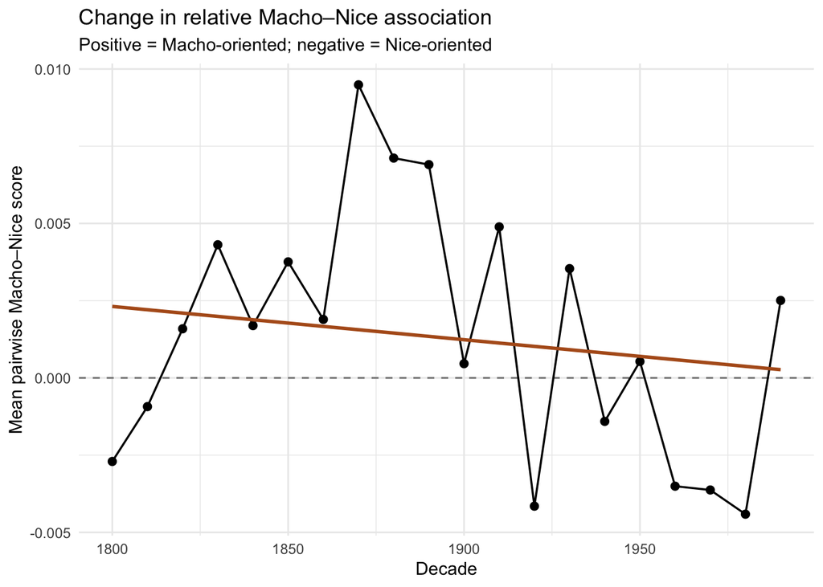

```r
rq1_data_pairwise_only<-rq1_data |>
  filter(method == "Pairwise delta" & approach == "Nudge") |>
  mutate(
    predicted_fit_1_2 = predict(rq1_2_fit),
  )

ggplot2::ggplot(
  rq1_data_pairwise_only,
  ggplot2::aes(
    x = decade,
    y = baseline_mean
  )
) +
  ggplot2::geom_hline(
    yintercept = 0,
    linetype = "dashed",
    color = "grey50"
  ) +
  ggplot2::geom_point(size = 2) +
  ggplot2::geom_line(linewidth = 0.6) +
  ggplot2::geom_line(
    ggplot2::aes(y = predicted_fit_1_2),
    color = "#B35C1E",
    linewidth = 1
  ) +
  ggplot2::labs(
    x = "Decade",
    y = "Mean pairwise Macho–Nice score",
    title = "Change in relative Macho–Nice association",
    subtitle = "Positive = Macho-oriented; negative = Nice-oriented"
  ) +
  ggplot2::theme_minimal()
```

**Caution**

The vocabulary baseline is a calibration quantity, not an automatic correction. Its sign and trend must be read from the model and sensitivity table above rather than assumed. A negative target score indicates absolute proximity to Nice Guy, but not necessarily a uniquely strong Nice association relative to the rest of the vocabulary.

Why the vocabulary baseline matters for our analysis; Attractiveness for example ?

Whenever the mean pairwise score of the broader vocabulary differs from zero, the absolute position of a target construct and its position relative to the general semantic background should be distinguished.

For example, suppose that in 1900 the mean pairwise score across the vocabulary is:

$$\bar{s}_{\text{vocabulary},t}=-.005$$

while the pairwise score for attractiveness is:

$$s_{\text{attractiveness},t}=-.002$$

Because the pairwise score is defined as similarity to Macho minus similarity to Nice Guy, the negative attractiveness score indicates that attractiveness is closer to the Nice Guy prototype than to the Macho prototype:

$$-.002 < 0$$

However, attractiveness is less negative than the vocabulary as a whole. Its position relative to the decade-specific semantic background is:

$$-.002-(-.005)=+.003$$

Thus, although attractiveness is **absolutely Nice-oriented**, it is **relatively more Macho-oriented than the average vocabulary word**.

This distinction motivates examining two complementary quantities:

**Absolute position:**

$$s_{\text{target},t}$$

This addresses whether the target is closer to the Macho or Nice Guy prototype, with zero representing equal similarity to both prototypes.

**Background-relative position:**

$$s^*_{\text{target},t}
=
s_{\text{target},t}
-
\bar{s}_{\text{vocabulary},t}$$

This addresses whether the target is more Macho- or Nice-oriented than the general vocabulary in the same decade. Positive adjusted scores indicate a more Macho-oriented position relative to the vocabulary background, whereas negative adjusted scores indicate a more Nice-oriented position.

This distinction is particularly important when examining **historical change**. Consider the following hypothetical pattern:

| Decade | Vocabulary mean | Attractiveness |
| --- | --- | --- |
| 1800 | -.002 | -.004 |
| 1900 | -.006 | -.008 |
| 1990 | -.010 | -.012 |

Considering attractiveness alone would suggest an increasingly Nice-oriented association over time:

$$-.004 \rightarrow -.008 \rightarrow -.012$$

However, subtracting the decade-specific vocabulary mean yields:

$$-.004-(-.002)=-.002$$

$$-.008-(-.006)=-.002$$

$$-.012-(-.010)=-.002$$

The background-adjusted association is therefore constant across time. In this example, attractiveness did **not** become specifically more Nice-oriented; rather, it changed in parallel with a broader shift in the vocabulary.

Accordingly, analyses of target constructs such as attractiveness and valence should consider both their raw pairwise scores and their decade-specific background-adjusted scores:

$$\boxed{
s^*_{\text{target},t}
=
s_{\text{target},t}
-
\bar{s}_{\text{vocabulary},t}
}$$

The raw score captures the target’s **absolute position between the two prototypes**, whereas the adjusted score captures its **specific position relative to the broader semantic background**. Examining both therefore distinguishes target-specific semantic change from shifts that characterize the vocabulary more generally.

Target-DDR analyses such as Attractiveness should therefore report both the raw score and, when theoretically relevant, the score relative to the decade-specific vocabulary mean. Rank-based trait analyses are unchanged by subtracting a common within-decade constant, and direct contrasts—such as casual versus long-term relationships—largely cancel a shared baseline. Prototype-distance analyses are unaffected because they measure separation between the Macho and Nice Guy prototypes directly.

### 4.1.1 Word-level analysis

*Q1.3: for each word, is its average score across decades reliably above or below zero?*

```r
one_sample_score_summary <- function(data,
 #                                    Adjusted_decade_mean =TRUE,
                                     min_n = 6) {

  # if (Adjusted_decade_mean & data$method == "Pairwise delta" & data$approach == "Nudge"){
  #   data <- data |>
  #     left_join(
  #       decade_mean_score,
  #       by = "decade"
  #     ) |>
  #     mutate(score = score - pairwise_mean_score) |>
  #     select(-pairwise_mean_score)
  # }



  x <- data$score
  n <- length(x)
  s <- if (n > 1) sd(x) else NA_real_ # in case a word appears only once in a decade, sd is NA, and we can't compute d_z


  null <- case_when(

    TRUE ~ 0
  )
  result <- tibble(
    n = n,
    mean_score = if (n > 0) mean(x) else NA_real_,
    median_score = if (n > 0) median(x) else NA_real_,
    sd_score = s,
    se = NA_real_,
    null_value = null,
    t_value = NA_real_,
    df = NA_real_,
    p_value = NA_real_,
    d_z = if (is.finite(s) && s > 0) {
      (mean(x) - null) / s
    } else {
      NA_real_
    },
    ci_low = NA_real_,
    ci_high = NA_real_,
    rho = NA_real_,
    model = "Descriptive"
  )


  # Avoid fitting unstable AR(1) models.
  if (n < min_n || !is.finite(s) || s == 0) { # s in infinite when there is no variance in x score across decades
    result$model <- "Insufficient data"
    return(result)
  }

  data$.time <- (data$decade - min(data$decade)) / 10 #the time variable is the decade number, starting from 1800 for the first decade in the data and increasing by 10 for each subsequent decade. This is to make it range from 1 to 20 instead of 1800 to 1990. AR1 would be unstable with the original decade numbers, so I rescale it to a smaller range.
  data$.score_centered <- data$score - null
  data <- data[order(data$.time), ]

  if (anyDuplicated(data$.time) ||
      any(abs(data$.time - round(data$.time)) > 1e-8)) {
    stop("AR(1) requires one observation per integer time point.")
  }

  fit <- tryCatch(
    nlme::gls(
      .score_centered ~ 1,
      data = data,
      method = "REML",
      correlation = nlme::corAR1(form = ~ .time)
    ),
    error = function(e) NULL
  )

  if (is.null(fit)) {
    result$model <- "AR1 failed"
    return(result)
  }

  test <- summary(fit)$tTable[1, ]
  df_value <- n - 1
  estimate <- unname(test["Value"]) + null
  se_value <- unname(test["Std.Error"])
  critical_t <- qt(0.975, df_value)

  result |>
    mutate(
      mean_score = estimate,
      n = n,
      se = se_value,
      t_value = unname(test["t-value"]),
      df = df_value,
      p_value = unname(test["p-value"]),
      d_z = (mean(x) - null) / s, # s=sd(score across decades for one word),
      d_gls = (estimate - null) / sigma(fit), #since estimate is not mean(score) but the mean of the AR1 model, we can compute d_gls as (estimate - null)/sd(score across decades for one word)

      ci_low = estimate - critical_t * se_value,
      ci_high = estimate + critical_t * se_value,
      rho = unname(
        coef(
          fit$modelStruct$corStruct,
          unconstrained = FALSE
        )
      ),
      model = "GLS AR(1)"
    )
}
```

```r
compare_nice_macho_words <- function(data) {


  data |>
    group_by(method, approach, word) |>
    group_modify(~ one_sample_score_summary(.x)) |>
    ungroup() |>
    left_join(
      data |>
        select(word, valence, arousal, dominance) |>
        distinct(),
      by = "word"
    ) |>
    mutate(
      direction = case_when(
        mean_score > 0 ~ "Macho",
        mean_score < 0 ~ "Nice",
        TRUE ~ "Neutral"
      ),
      p_fdr = p.adjust(p_value, method = "fdr"),
      sig = case_when(
        is.na(p_fdr) ~ "No",
        p_fdr < 0.001 ~ "***",
        p_fdr < 0.01 ~ "**",
        p_fdr < 0.05 ~ "*",
        TRUE ~ "No"
      )
    ) |>
    arrange(method, approach, p_fdr)
}
```

```r
# Optional lexicon-wide exploratory analysis. This fits a separate AR(1) model
# for every word, method, and approach, so it is intentionally not run during
# the standard manuscript render.
word_summary_all <- compare_nice_macho_words(
  method_scores_long
  )

table(word_summary_all |> filter( method == "Pairwise delta" & approach == "Nudge" & sig != "No" ) |> pull(direction)  )
```

[output not shown]

out of the 75662 words in the corpus, that has had enough embedding to be included in the analysis, 8619 words are significantly associated with Macho and 8742 words are significantly associated with Nice.

```r
word_summary_all |>
  filter(sig != "No") |>
  mutate( score_rank = rank(-abs(d_z), ties.method = "first")) |>
  group_by(method, approach, direction) |>
  arrange( score_rank, .by_group = TRUE) |>
  slice_head(n = 10) |>
  ungroup() |>
  select(method, approach, direction, word, n, mean_score, d_z, p_value, p_fdr, sig) |>
  kable(
    caption = "Top word-level Macho/Nice scores across decades by method and approach",
    digits = 3
  )
```

[output not shown]

**Which traits are most consistently pulled toward Macho and Nice Guy across decades?**

To keep this interpretable, I focus here on the rated trait words rather than the full vocabulary. The goal is simple: average each trait’s score across decades, keep the significant trait-level results, and then inspect the strongest positive effects (Macho) and strongest negative effects (Nice).

```r
word_summary_traits <- method_scores_long |>
  filter(word %in% traits_warriner$word) |>
  compare_nice_macho_words()



top_signed_traits <- function(data, top_n = 10) {
  data |>
    filter(sig != "No", n >5) |> # Appearing in at least in 5 decades
    mutate(
      sort_score = if_else(direction == "Macho", d_z, -d_z) # used just for the arranged
    ) |>
    group_by(method, approach, direction) |>
    slice_max(order_by = sort_score, n = top_n, with_ties = FALSE) |>
    arrange(method, approach, direction, desc(sort_score), .by_group = TRUE) |>
    mutate(rank = row_number()) |>
    ungroup()
}

top_trait_summary <- top_signed_traits(word_summary_traits, top_n = 10)

prepare_trait_table <- function(data, focal_direction) {
  data |>
    filter(direction == focal_direction) |>
    transmute(
      Method = method,
      Approach = approach,
      Rank = rank,
      Trait = word,
      M = apa_num(mean_score, 2),
      `95% CI` = apa_ci(ci_low, ci_high, 2),
      d_z = apa_num(d_z, 2),
      `p (FDR)` = apa_p(p_fdr)
    )
}
```

Before the plot, I keep just the top five traits per method, approach, and direction. If the same trait appears in several method panels, I show it only once within the Macho or Nice row and leave the point visible only in the columns where that trait belongs to the top five. I still use a forest-style plot so the mean trait score and its 95% confidence interval are both visible.

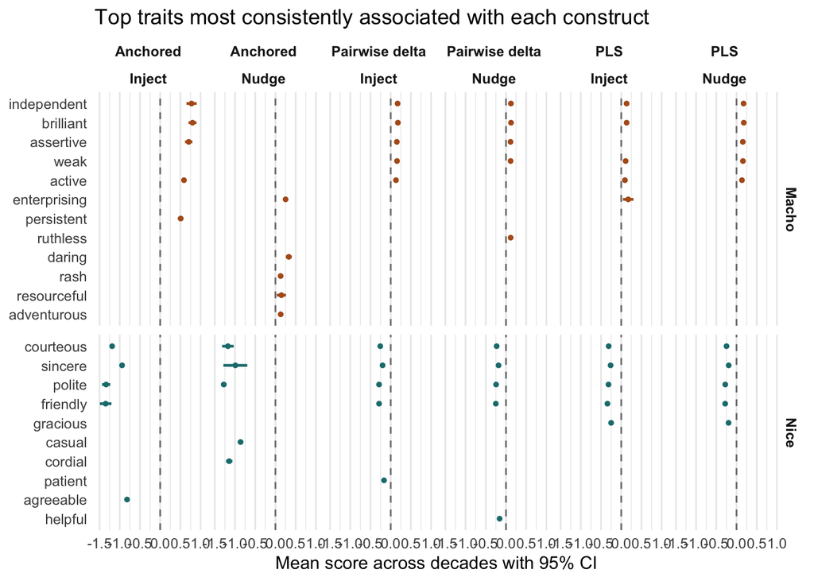

```r
top_trait_plot_data <- top_signed_traits(word_summary_traits, top_n = 5)

trait_row_order <- top_trait_plot_data |>
  group_by(direction, word) |>
  summarise(
    n_panels = n(),
    mean_priority = mean(sort_score, na.rm = TRUE),
    .groups = "drop"
  ) |>
  arrange(direction, desc(n_panels), desc(mean_priority), word) |>
  mutate(direction_word = paste(direction, word, sep = "___"))

top_trait_plot_data <- top_trait_plot_data |>
  left_join(
    trait_row_order |>
      select(direction, word, direction_word),
    by = c("direction", "word")
  ) |>
  mutate(
    direction_word = factor(
      direction_word,
      levels = rev(trait_row_order$direction_word)
    )
  )

ggplot(
  top_trait_plot_data,
  aes(x = mean_score, y = direction_word, color = direction)
) +
  geom_vline(xintercept = 0, linetype = "dashed", color = "gray50") +
  geom_segment(
    aes(
      x = ci_low,
      xend = ci_high,
      y = direction_word,
      yend = direction_word
    ),
    linewidth = 0.8,
    show.legend = FALSE
  ) +
  geom_point(size = 1, show.legend = FALSE) +
  facet_grid(direction ~ method + approach, scales = "free_y", space = "free_y") +
  scale_y_discrete(labels = function(x) sub("^[^_]+___", "", x)) +
  scale_color_manual(values = c(Macho = "#B35C1E", Nice = "#1C7C7D")) +
  labs(
    title = "Top traits most consistently associated with each construct",
    x = "Mean score across decades with 95% CI",
    y = NULL
  ) +
  theme_minimal(base_size = 11) +
  theme(
    strip.text = element_text(face = "bold"),
    panel.grid.major.y = element_blank()
  )
```

The tables below give the same result in a more readable format. I split them into Macho and Nice so each side of the contrast can be scanned on its own.

```r
prepare_trait_table(top_trait_summary, "Macho") |>
  kable(
    caption = "Top Macho-leaning traits across decades",
    align = c("l", "l", "r", "l", "r", "l", "r", "l")
  )
```

Top Macho-leaning traits across decades

| Method | Approach | Rank | Trait | M | 95% CI | d_z | p (FDR) |
| --- | --- | --- | --- | --- | --- | --- | --- |
| Anchored | Inject | 1 | assertive | 0.71 | [0.61, 0.80] | 6.15 | < .001 |
| Anchored | Inject | 2 | independent | 0.78 | [0.65, 0.90] | 5.89 | < .001 |
| Anchored | Inject | 3 | active | 0.59 | [0.54, 0.64] | 5.83 | < .001 |
| Anchored | Inject | 4 | brilliant | 0.80 | [0.70, 0.90] | 5.60 | < .001 |
| Anchored | Inject | 5 | persistent | 0.51 | [0.44, 0.58] | 5.31 | < .001 |
| Anchored | Inject | 6 | aggressive | 0.97 | [0.34, 1.60] | 4.74 | .010 |
| Anchored | Inject | 7 | weak | 0.70 | [0.64, 0.77] | 4.72 | < .001 |
| Anchored | Inject | 8 | courageous | 0.72 | [0.66, 0.79] | 4.69 | < .001 |
| Anchored | Inject | 9 | ruthless | 0.70 | [0.55, 0.85] | 4.20 | < .001 |
| Anchored | Inject | 10 | energetic | 0.90 | [0.69, 1.11] | 4.11 | < .001 |
| Anchored | Nudge | 1 | enterprising | 0.25 | [0.20, 0.31] | 3.29 | < .001 |
| Anchored | Nudge | 2 | daring | 0.33 | [0.26, 0.40] | 2.36 | < .001 |
| Anchored | Nudge | 3 | rash | 0.13 | [0.07, 0.19] | 1.14 | < .001 |
| Anchored | Nudge | 4 | resourceful | 0.15 | [0.03, 0.26] | 1.11 | .028 |
| Anchored | Nudge | 5 | adventurous | 0.13 | [0.07, 0.18] | 1.03 | < .001 |
| PLS | Inject | 1 | brilliant | 0.13 | [0.11, 0.15] | 5.07 | < .001 |
| PLS | Inject | 2 | independent | 0.13 | [0.11, 0.16] | 4.55 | < .001 |
| PLS | Inject | 3 | weak | 0.11 | [0.10, 0.12] | 4.34 | < .001 |
| PLS | Inject | 4 | enterprising | 0.17 | [0.04, 0.30] | 3.58 | .022 |
| PLS | Inject | 5 | active | 0.09 | [0.07, 0.11] | 3.45 | < .001 |
| PLS | Inject | 6 | ruthless | 0.12 | [0.10, 0.15] | 3.44 | < .001 |
| PLS | Inject | 7 | courageous | 0.11 | [0.09, 0.13] | 3.43 | < .001 |
| PLS | Inject | 8 | dominant | 0.14 | [0.10, 0.19] | 3.30 | < .001 |
| PLS | Inject | 9 | assertive | 0.09 | [0.06, 0.12] | 3.05 | < .001 |
| PLS | Inject | 10 | daring | 0.17 | [0.11, 0.22] | 2.65 | < .001 |
| PLS | Nudge | 1 | independent | 0.17 | [0.15, 0.20] | 7.52 | < .001 |
| PLS | Nudge | 2 | brilliant | 0.18 | [0.16, 0.20] | 6.86 | < .001 |
| PLS | Nudge | 3 | assertive | 0.16 | [0.13, 0.18] | 6.05 | < .001 |
| PLS | Nudge | 4 | weak | 0.16 | [0.15, 0.17] | 5.57 | < .001 |
| PLS | Nudge | 5 | active | 0.13 | [0.12, 0.15] | 5.22 | < .001 |
| PLS | Nudge | 6 | courageous | 0.16 | [0.15, 0.18] | 4.79 | < .001 |
| PLS | Nudge | 7 | persistent | 0.11 | [0.10, 0.13] | 4.57 | < .001 |
| PLS | Nudge | 8 | energetic | 0.20 | [0.14, 0.25] | 4.54 | < .001 |
| PLS | Nudge | 9 | ruthless | 0.15 | [0.12, 0.19] | 4.37 | < .001 |
| PLS | Nudge | 10 | forceful | 0.14 | [0.13, 0.16] | 4.26 | < .001 |
| Pairwise delta | Inject | 1 | independent | 0.17 | [0.15, 0.19] | 7.90 | < .001 |
| Pairwise delta | Inject | 2 | brilliant | 0.18 | [0.16, 0.20] | 6.39 | < .001 |
| Pairwise delta | Inject | 3 | weak | 0.16 | [0.15, 0.17] | 5.86 | < .001 |
| Pairwise delta | Inject | 4 | assertive | 0.15 | [0.12, 0.18] | 5.46 | < .001 |
| Pairwise delta | Inject | 5 | active | 0.13 | [0.11, 0.15] | 4.68 | < .001 |
| Pairwise delta | Inject | 6 | ruthless | 0.16 | [0.13, 0.19] | 4.67 | < .001 |
| Pairwise delta | Inject | 7 | aggressive | 0.20 | [0.02, 0.37] | 4.57 | .046 |
| Pairwise delta | Inject | 8 | persistent | 0.11 | [0.09, 0.13] | 4.50 | < .001 |
| Pairwise delta | Inject | 9 | forceful | 0.14 | [0.12, 0.15] | 4.41 | < .001 |
| Pairwise delta | Inject | 10 | courageous | 0.16 | [0.14, 0.17] | 4.37 | < .001 |
| Pairwise delta | Nudge | 1 | independent | 0.12 | [0.11, 0.14] | 6.31 | < .001 |
| Pairwise delta | Nudge | 2 | assertive | 0.11 | [0.10, 0.13] | 5.61 | < .001 |
| Pairwise delta | Nudge | 3 | brilliant | 0.12 | [0.10, 0.15] | 5.37 | < .001 |
| Pairwise delta | Nudge | 4 | weak | 0.11 | [0.10, 0.12] | 4.89 | < .001 |
| Pairwise delta | Nudge | 5 | ruthless | 0.12 | [0.09, 0.14] | 4.34 | < .001 |
| Pairwise delta | Nudge | 6 | persistent | 0.08 | [0.06, 0.09] | 4.00 | < .001 |
| Pairwise delta | Nudge | 7 | courageous | 0.10 | [0.09, 0.11] | 3.76 | < .001 |
| Pairwise delta | Nudge | 8 | active | 0.09 | [0.07, 0.10] | 3.55 | < .001 |
| Pairwise delta | Nudge | 9 | daring | 0.16 | [0.12, 0.20] | 3.43 | < .001 |
| Pairwise delta | Nudge | 10 | rash | 0.12 | [0.09, 0.15] | 3.41 | < .001 |

```r
prepare_trait_table(top_trait_summary, "Nice") |>
  kable(
    caption = "Top Nice-leaning traits across decades",
    align = c("l", "l", "r", "l", "r", "l", "r", "l")
  )
```

Top Nice-leaning traits across decades

| Method | Approach | Rank | Trait | M | 95% CI | d_z | p (FDR) |
| --- | --- | --- | --- | --- | --- | --- | --- |
| Anchored | Inject | 1 | courteous | -1.19 | [-1.23, -1.15] | -11.43 | < .001 |
| Anchored | Inject | 2 | sincere | -0.94 | [-1.00, -0.88] | -8.45 | < .001 |
| Anchored | Inject | 3 | polite | -1.34 | [-1.44, -1.24] | -7.88 | < .001 |
| Anchored | Inject | 4 | friendly | -1.35 | [-1.49, -1.20] | -6.99 | < .001 |
| Anchored | Inject | 5 | agreeable | -0.82 | [-0.88, -0.76] | -6.15 | < .001 |
| Anchored | Inject | 6 | gracious | -0.95 | [-1.07, -0.84] | -5.82 | < .001 |
| Anchored | Inject | 7 | patient | -0.79 | [-0.90, -0.67] | -5.29 | < .001 |
| Anchored | Inject | 8 | helpful | -0.81 | [-0.91, -0.70] | -4.93 | < .001 |
| Anchored | Inject | 9 | curious | -0.66 | [-0.72, -0.59] | -4.90 | < .001 |
| Anchored | Inject | 10 | generous | -0.65 | [-0.73, -0.57] | -4.52 | < .001 |
| Anchored | Nudge | 1 | polite | -1.28 | [-1.35, -1.21] | -9.46 | < .001 |
| Anchored | Nudge | 2 | casual | -0.86 | [-0.93, -0.80] | -9.23 | < .001 |
| Anchored | Nudge | 3 | courteous | -1.18 | [-1.32, -1.03] | -8.45 | < .001 |
| Anchored | Nudge | 4 | sincere | -0.99 | [-1.29, -0.70] | -7.19 | < .001 |
| Anchored | Nudge | 5 | cordial | -1.14 | [-1.22, -1.07] | -7.14 | < .001 |
| Anchored | Nudge | 6 | generous | -0.82 | [-0.90, -0.74] | -6.80 | < .001 |
| Anchored | Nudge | 7 | helpful | -0.89 | [-1.01, -0.78] | -6.72 | < .001 |
| Anchored | Nudge | 8 | agreeable | -0.93 | [-1.02, -0.84] | -6.68 | < .001 |
| Anchored | Nudge | 9 | patient | -0.91 | [-1.04, -0.78] | -6.59 | < .001 |
| Anchored | Nudge | 10 | wholesome | -0.76 | [-0.85, -0.67] | -6.53 | < .001 |
| PLS | Inject | 1 | courteous | -0.31 | [-0.33, -0.30] | -12.75 | < .001 |
| PLS | Inject | 2 | friendly | -0.34 | [-0.35, -0.33] | -11.78 | < .001 |
| PLS | Inject | 3 | sincere | -0.26 | [-0.29, -0.23] | -8.16 | < .001 |
| PLS | Inject | 4 | gracious | -0.25 | [-0.28, -0.22] | -6.36 | < .001 |
| PLS | Inject | 5 | polite | -0.32 | [-0.37, -0.26] | -6.07 | < .001 |
| PLS | Inject | 6 | agreeable | -0.22 | [-0.24, -0.20] | -6.00 | < .001 |
| PLS | Inject | 7 | tender | -0.26 | [-0.31, -0.20] | -5.70 | < .001 |
| PLS | Inject | 8 | curious | -0.15 | [-0.16, -0.13] | -5.56 | < .001 |
| PLS | Inject | 9 | humble | -0.22 | [-0.25, -0.19] | -5.53 | < .001 |
| PLS | Inject | 10 | generous | -0.20 | [-0.24, -0.16] | -5.34 | < .001 |
| PLS | Nudge | 1 | courteous | -0.25 | [-0.26, -0.23] | -9.46 | < .001 |
| PLS | Nudge | 2 | friendly | -0.28 | [-0.30, -0.26] | -9.27 | < .001 |
| PLS | Nudge | 3 | sincere | -0.19 | [-0.21, -0.18] | -7.49 | < .001 |
| PLS | Nudge | 4 | polite | -0.28 | [-0.31, -0.24] | -6.83 | < .001 |
| PLS | Nudge | 5 | gracious | -0.20 | [-0.22, -0.18] | -6.04 | < .001 |
| PLS | Nudge | 6 | agreeable | -0.17 | [-0.19, -0.15] | -5.44 | < .001 |
| PLS | Nudge | 7 | patient | -0.16 | [-0.19, -0.14] | -5.39 | < .001 |
| PLS | Nudge | 8 | compassionate | -0.20 | [-0.23, -0.17] | -4.80 | < .001 |
| PLS | Nudge | 9 | curious | -0.13 | [-0.15, -0.12] | -4.78 | < .001 |
| PLS | Nudge | 10 | helpful | -0.17 | [-0.19, -0.15] | -4.77 | < .001 |
| Pairwise delta | Inject | 1 | courteous | -0.26 | [-0.29, -0.23] | -7.58 | < .001 |
| Pairwise delta | Inject | 2 | polite | -0.29 | [-0.31, -0.26] | -7.32 | < .001 |
| Pairwise delta | Inject | 3 | friendly | -0.29 | [-0.33, -0.25] | -7.22 | < .001 |
| Pairwise delta | Inject | 4 | sincere | -0.20 | [-0.22, -0.18] | -7.03 | < .001 |
| Pairwise delta | Inject | 5 | patient | -0.17 | [-0.18, -0.15] | -6.62 | < .001 |
| Pairwise delta | Inject | 6 | gracious | -0.20 | [-0.23, -0.17] | -5.28 | < .001 |
| Pairwise delta | Inject | 7 | agreeable | -0.18 | [-0.19, -0.16] | -5.22 | < .001 |
| Pairwise delta | Inject | 8 | helpful | -0.17 | [-0.19, -0.16] | -4.84 | < .001 |
| Pairwise delta | Inject | 9 | cordial | -0.24 | [-0.28, -0.21] | -4.80 | < .001 |
| Pairwise delta | Inject | 10 | curious | -0.14 | [-0.15, -0.12] | -4.74 | < .001 |
| Pairwise delta | Nudge | 1 | friendly | -0.25 | [-0.27, -0.23] | -9.76 | < .001 |
| Pairwise delta | Nudge | 2 | sincere | -0.18 | [-0.20, -0.17] | -8.59 | < .001 |
| Pairwise delta | Nudge | 3 | courteous | -0.23 | [-0.26, -0.21] | -7.55 | < .001 |
| Pairwise delta | Nudge | 4 | polite | -0.24 | [-0.29, -0.20] | -6.11 | < .001 |
| Pairwise delta | Nudge | 5 | helpful | -0.16 | [-0.18, -0.14] | -5.82 | < .001 |
| Pairwise delta | Nudge | 6 | gracious | -0.18 | [-0.20, -0.15] | -5.59 | < .001 |
| Pairwise delta | Nudge | 7 | compassionate | -0.17 | [-0.19, -0.16] | -5.48 | < .001 |
| Pairwise delta | Nudge | 8 | patient | -0.13 | [-0.15, -0.11] | -5.48 | < .001 |
| Pairwise delta | Nudge | 9 | generous | -0.14 | [-0.16, -0.12] | -5.12 | < .001 |
| Pairwise delta | Nudge | 10 | tender | -0.17 | [-0.21, -0.13] | -5.01 | < .001 |

Let’s validate that those top traits are indeed rated as more positive or negative in Warriner’s Dominance norms.

```r
prepare_trait_table(top_trait_summary, "Macho") |>
  left_join(
    traits_warriner |>
      select(word, dominance,valence),
    by = c("Trait" = "word")
  ) |>
  group_by(Method, Approach) |>
  summarise(
    mean_dominance = mean(dominance, na.rm = TRUE),
    sd_dominance = sd(dominance, na.rm = TRUE),
    mean_valence = mean(valence, na.rm = TRUE),
    sd_valence = sd(valence, na.rm = TRUE),
    .groups = "drop"
  ) |>
  kable(
    caption = "Mean dominance and valence of top Macho-leaning traits across decades",
    digits = 2,
    align = c("l", "l", "r", "r","r", "r")
  )
```

Mean dominance and valence of top Macho-leaning traits across decades

| Method | Approach | mean_dominance | sd_dominance | mean_valence | sd_valence |
| --- | --- | --- | --- | --- | --- |
| Anchored | Inject | 6.12 | 1.04 | 5.72 | 1.91 |
| Anchored | Nudge | 5.49 | 1.42 | 5.86 | 1.71 |
| PLS | Inject | 6.26 | 1.03 | 5.75 | 1.59 |
| PLS | Nudge | 6.12 | 1.04 | 5.78 | 1.82 |
| Pairwise delta | Inject | 6.09 | 1.05 | 5.34 | 1.89 |
| Pairwise delta | Nudge | 5.89 | 1.43 | 5.57 | 1.79 |

```r
# do the same for Nice traits


prepare_trait_table(top_trait_summary, "Nice") |>
  left_join(
    traits_warriner |>
      select(word, dominance,valence),
    by = c("Trait" = "word")
  ) |>
  group_by(Method, Approach) |>
  summarise(
    mean_dominance = mean(dominance, na.rm = TRUE),
    sd_dominance = sd(dominance, na.rm = TRUE),
    mean_valence = mean(valence, na.rm = TRUE),
    sd_valence = sd(valence, na.rm = TRUE),
    .groups = "drop"
  ) |>
  kable(
    caption = "Mean dominance and valence of top Nice-leaning traits across decades",
    digits = 2,
    align = c("l", "l", "r", "r","r", "r")
  )
```

Mean dominance and valence of top Nice-leaning traits across decades

| Method | Approach | mean_dominance | sd_dominance | mean_valence | sd_valence |
| --- | --- | --- | --- | --- | --- |
| Anchored | Inject | 6.88 | 0.77 | 7.06 | 0.42 |
| Anchored | Nudge | 6.57 | 0.84 | 6.83 | 0.43 |
| PLS | Inject | 6.93 | 0.53 | 6.94 | 0.45 |
| PLS | Nudge | 6.88 | 0.77 | 7.11 | 0.49 |
| Pairwise delta | Inject | 6.74 | 0.90 | 6.96 | 0.44 |
| Pairwise delta | Nudge | 6.77 | 0.83 | 7.15 | 0.51 |

It seems that the Macho-associated traits supprisngly have score less dominance than the nice-associated traits. also, there’s more variance (SD) in valence and dominance for Macho-associated words compared to Nice-associated traits.

## 4.2 Q3 - Valence

**Did the mean valence of the traits most strongly aligned with the Macho and Nice Guy prototypes change across decades?**

The primary analysis uses the Pairwise Delta scoring method with the Nudge construct-building approach. Within each decade, I identify the ten words with the highest scores as the most Macho-leaning words and the ten traits with the lowest scores as the most Nice Guy–leaning warriner list words

```r
select_top_words_by_decade <- function(data,
                                        top_n = 10){


  data |>
    filter(
      word %in% warriner$word, #all warrier words
      direction != "Neutral"
    ) |>
    mutate(
      rank_score = if_else(direction == "Macho", score, -score)
    ) |>
    group_by(method, approach, decade, decade_num, direction) |>
    slice_max(order_by = rank_score, n = top_n, with_ties = FALSE) |>
    ungroup()
}

top_words_decade_scores <- select_top_words_by_decade(
  method_scores_long,
  # UNCOMMENT TO CHECK IF THE TREND IS DRIVEN BY NEW WORDS THAT BECOME AVAILABLE IN LATER DECADES, POST-HOC: THERE NOT-------------------
  # |>
  #  group_by(word) |>
  #  filter(n_distinct(decade) == length(decades)) |>
  #  ungroup(),

  #----------
  top_n = 10
)

top_words_valence_by_decade <- top_words_decade_scores |>
  group_by(method, approach, decade, direction, decade_num) |>
  summarise(
    n_words = n(),
    mean_valence_centered = mean(valence_centered, na.rm = TRUE),
    sd_valence_centered = sd(valence_centered, na.rm = TRUE),
    se_valence = if_else(
      n_words > 1,
      sd_valence_centered / sqrt(n_words),
      NA_real_
    ),
    t_crit = if_else(
      n_words > 1,
      qt(0.975, df = n_words - 1),
      NA_real_
    ),
    ci_low = mean_valence_centered - (t_crit * se_valence),
    ci_high = mean_valence_centered + (t_crit * se_valence),
    mean_score = mean(score, na.rm = TRUE),
    .groups = "drop"
  ) |>
  left_join(
    avwords_n_decade_df |>
      select(decade, n_avwords, prop_avail),
    by = "decade"
  ) |>
  group_by(method, approach, direction) |>
  arrange(decade, .by_group = TRUE) |>
  mutate(
    time_decades = (decade - min(decade)) / 10,
    decade_index = row_number()
  ) |>
  ungroup()
```

```r
warriner_valence_plot <- ggplot(
  top_words_valence_by_decade,
  aes(
    x = decade_num,
    y = mean_valence_centered,
    color = direction,
    fill = direction,
    group = direction
  )
) +
  geom_hline(yintercept = 0, linetype = "dashed", color = "gray50") +
  geom_ribbon(
    aes(ymin = ci_low, ymax = ci_high),
    alpha = 0.15,
    color = NA,
    show.legend = FALSE
  ) +
  geom_line(linewidth = 0.8) +
  geom_point(size = 1.6) +
  facet_grid(approach ~ method) +
  scale_color_manual(values = c(Macho = "#B35C1E", Nice = "#1C7C7D")) +
  scale_fill_manual(values = c(Macho = "#B35C1E", Nice = "#1C7C7D")) +
  labs(
    title = "Mean valence of the top 10 words within each decade",
    x = "Decade",
    y = "Mean centered valence",
    color = NULL
  ) +
  theme_minimal(base_size = 11) +
  theme(
    strip.text = element_text(face = "bold"),
    legend.position = "top"
  )
```

Before fitting the formal trend model, I first check whether these decade-level valence trajectories show **tracking**. The issue is the same as in the split analysis: if adjacent decades still move together after a basic linear trend is removed, then a standard independent-errors model will understate uncertainty. That would make the valence shift look more precise than it really is.

I therefore fit a simple OLS line within each `method x approach x direction` panel only for diagnostic purposes, and I inspect the lag-1 residual correlation and the largest studentized residual. Positive lag-1 correlations indicate decade-to-decade carryover, whereas very large studentized residuals indicate a potentially influential decade.

```r
top_words_valence_tracking_df <- top_words_valence_by_decade |>
  group_by(method, approach, direction) |>
  group_modify(~ {
    fit <- lm(mean_valence_centered ~ time_decades, data = .x)

    tibble(
      decade = .x$decade,
      residual = resid(fit),
      studentized = rstudent(fit)
    )
  }) |>
  ungroup()

top_words_valence_tracking_summary <- top_words_valence_tracking_df |>
  group_by(method, approach, direction) |>
  summarise(
    lag1_residual_correlation = cor(residual[-n()], residual[-1]),
    max_abs_studentized = max(abs(studentized), na.rm = TRUE),
    n_abs_studentized_gt3 = sum(abs(studentized) > 3, na.rm = TRUE),
    .groups = "drop"
  )

kable(
  top_words_valence_tracking_summary,
  digits = 3,
  caption = "Residual diagnostics for tracking in the top-word valence trajectories"
)
```

Residual diagnostics for tracking in the top-word valence trajectories

| method | approach | direction | lag1_residual_correlation | max_abs_studentized | n_abs_studentized_gt3 |
| --- | --- | --- | --- | --- | --- |
| Anchored | Inject | Macho | -0.378 | 2.255 | 0 |
| Anchored | Inject | Nice | -0.165 | 2.264 | 0 |
| Anchored | Nudge | Macho | -0.378 | 2.255 | 0 |
| Anchored | Nudge | Nice | -0.165 | 2.264 | 0 |
| PLS | Inject | Macho | -0.264 | 2.214 | 0 |
| PLS | Inject | Nice | -0.006 | 2.543 | 0 |
| PLS | Nudge | Macho | -0.378 | 2.255 | 0 |
| PLS | Nudge | Nice | -0.165 | 2.264 | 0 |
| Pairwise delta | Inject | Macho | -0.281 | 2.697 | 0 |
| Pairwise delta | Inject | Nice | -0.213 | 2.713 | 0 |
| Pairwise delta | Nudge | Macho | -0.345 | 1.985 | 0 |
| Pairwise delta | Nudge | Nice | 0.178 | 2.339 | 0 |

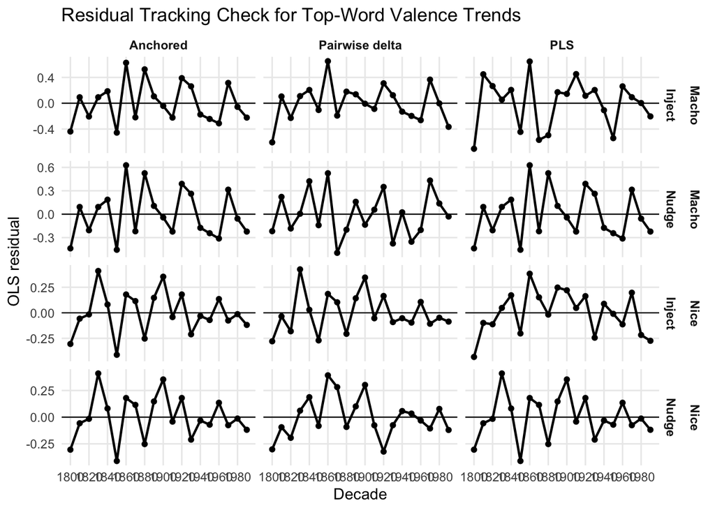

```r
ggplot(
  top_words_valence_tracking_df,
  aes(x = decade, y = residual)
) +
  geom_hline(yintercept = 0, linewidth = 0.4) +
  geom_line(linewidth = 0.8) +
  geom_point(size = 1.4) +
  facet_grid(direction + approach ~ method, scales = "free_y") +
  scale_x_continuous(
    breaks = seq(1800, 1990, by = 20)
  ) +
  labs(
    title = "Residual Tracking Check for Top-Word Valence Trends",
    x = "Decade",
    y = "OLS residual"
  ) +
  theme_minimal(base_size = 11) +
  theme(
    strip.text = element_text(face = "bold"),
    panel.grid.minor = element_blank()
  )
```

The table below reports the **linear GLS trend** for each panel. The slope is interpreted per decade because `time_decades` is measured in 10-year units. The confidence interval is a Wald interval around that slope estimate.

```r
top_words_valence_trends <- top_words_valence_by_decade |>
  group_by(method, approach, direction) |>
  group_modify(~ {
    fit <- nlme::gls(
      mean_valence_centered ~ time_decades,
      data = .x,
      correlation = nlme::corAR1(form = ~ decade_index),
      weights = nlme::varFixed(~ I(1 / n_avwords)),
      method = "ML"
    )

    fit_table <- summary(fit)$tTable
    slope_estimate <- unname(fit_table["time_decades", "Value"])
    slope_se <- unname(fit_table["time_decades", "Std.Error"])

    start_row <- .x |>
      arrange(decade) |>
      slice_head(n = 1)

    end_row <- .x |>
      arrange(decade) |>
      slice_tail(n = 1)

    tibble(
      start_decade = start_row$decade,
      start_mean = start_row$mean_valence_centered,
      start_ci_low = start_row$ci_low,
      start_ci_high = start_row$ci_high,
      end_decade = end_row$decade,
      end_mean = end_row$mean_valence_centered,
      end_ci_low = end_row$ci_low,
      end_ci_high = end_row$ci_high,
      change_across_period = end_row$mean_valence_centered - start_row$mean_valence_centered,
      slope_per_decade = slope_estimate,
      slope_ci_low = slope_estimate - qnorm(0.975) * slope_se,
      slope_ci_high = slope_estimate + qnorm(0.975) * slope_se,
      p_value = fit_table["time_decades", "p-value"],
      ar1_phi = unname(
        coef(fit$modelStruct$corStruct, unconstrained = FALSE)
      )
    )
  }) |>
  ungroup()

top_words_valence_trends |>
  transmute(
    Method = method,
    Approach = approach,
    Direction = direction,
    Start = paste0(
      start_decade,
      ": ",
      apa_num(start_mean, 2),
      " ",
      apa_ci(start_ci_low, start_ci_high, 2)
    ),
    End = paste0(
      end_decade,
      ": ",
      apa_num(end_mean, 2),
      " ",
      apa_ci(end_ci_low, end_ci_high, 2)
    ),
    `Change in M` = apa_num(change_across_period, 2),
    `Slope b` = apa_num(slope_per_decade, 3),
    `95% CI for b` = apa_ci(slope_ci_low, slope_ci_high, 3),
    `AR(1) phi` = apa_num(ar1_phi, 3),
    p = apa_p(p_value)
  ) |>
  kable(
    caption = "Weighted GLS linear change in the valence of the top 10 traits within each decade",
    align = c("l", "l", "l", "l", "l", "r", "r", "l", "r", "l")
  )
```

Weighted GLS linear change in the valence of the top 10 traits within each decade

| Method | Approach | Direction | Start | End | Change in M | Slope b | 95% CI for b | AR(1) phi | p |
| --- | --- | --- | --- | --- | --- | --- | --- | --- | --- |
| Anchored | Inject | Macho | 1800: -0.50 [-1.44, 0.45] | 1990: -0.38 [-1.12, 0.36] | 0.12 | -0.012 | [-0.029, 0.006] | -0.337 | .207 |
| Anchored | Inject | Nice | 1800: 1.27 [0.52, 2.02] | 1990: 1.96 [1.52, 2.39] | 0.69 | 0.023 | [0.010, 0.035] | -0.204 | .003 |
| Anchored | Nudge | Macho | 1800: -0.50 [-1.44, 0.45] | 1990: -0.38 [-1.12, 0.36] | 0.12 | -0.012 | [-0.029, 0.006] | -0.337 | .207 |
| Anchored | Nudge | Nice | 1800: 1.27 [0.52, 2.02] | 1990: 1.96 [1.52, 2.39] | 0.69 | 0.023 | [0.010, 0.035] | -0.204 | .003 |
| PLS | Inject | Macho | 1800: -0.94 [-1.84, -0.03] | 1990: -0.73 [-1.56, 0.09] | 0.20 | -0.019 | [-0.042, 0.004] | -0.206 | .120 |
| PLS | Inject | Nice | 1800: 1.19 [0.37, 2.01] | 1990: 1.92 [1.35, 2.48] | 0.73 | 0.020 | [0.005, 0.036] | -0.069 | .016 |
| PLS | Nudge | Macho | 1800: -0.50 [-1.44, 0.45] | 1990: -0.38 [-1.12, 0.36] | 0.12 | -0.012 | [-0.029, 0.006] | -0.337 | .207 |
| PLS | Nudge | Nice | 1800: 1.27 [0.52, 2.02] | 1990: 1.96 [1.52, 2.39] | 0.69 | 0.023 | [0.010, 0.035] | -0.204 | .003 |
| Pairwise delta | Inject | Macho | 1800: -0.68 [-1.71, 0.36] | 1990: -0.58 [-1.32, 0.16] | 0.10 | -0.015 | [-0.032, 0.001] | -0.295 | .084 |
| Pairwise delta | Inject | Nice | 1800: 1.27 [0.52, 2.02] | 1990: 2.03 [1.58, 2.47] | 0.76 | 0.025 | [0.014, 0.036] | -0.222 | < .001 |
| Pairwise delta | Nudge | Macho | 1800: -0.49 [-1.43, 0.44] | 1990: -0.38 [-1.12, 0.36] | 0.12 | -0.001 | [-0.019, 0.017] | -0.259 | .882 |
| Pairwise delta | Nudge | Nice | 1800: 1.35 [0.65, 2.05] | 1990: 1.98 [1.53, 2.43] | 0.63 | 0.018 | [0.003, 0.033] | 0.094 | .029 |

Because historical change may be curved rather than perfectly linear, I also compare the linear GLS model to a **3 df natural spline GLS model** for each panel. A small likelihood-ratio p-value means the curved model fits better than a single straight line.

```r
top_words_valence_spline_table <- top_words_valence_by_decade |>
  group_by(method, approach, direction) |>
  group_modify(~ {
    fit_linear <- nlme::gls(
      mean_valence_centered ~ time_decades,
      data = .x,
      correlation = nlme::corAR1(form = ~ decade_index),
      weights = nlme::varFixed(~ I(1 / n_avwords)),
      method = "ML"
    )

    fit_spline <- nlme::gls(
      mean_valence_centered ~ splines::ns(time_decades, df = 3),
      data = .x,
      correlation = nlme::corAR1(form = ~ decade_index),
      weights = nlme::varFixed(~ I(1 / n_avwords)),
      method = "ML"
    )

    model_comparison <- anova(fit_linear, fit_spline)

    tibble(
      linear_aic = AIC(fit_linear),
      spline_aic = AIC(fit_spline),
      lr_p_value = model_comparison$`p-value`[2],
      better_model = case_when(
        AIC(fit_spline) + 2 < AIC(fit_linear) ~ "Spline",
        AIC(fit_linear) + 2 < AIC(fit_spline) ~ "Linear",
        TRUE ~ "Similar fit"
      )
    )
  }) |>
  ungroup()

top_words_valence_spline_table |>
  kable(
    digits = 4,
    caption = "Spline sensitivity checks for the top-word valence trajectories"
  )
```

Spline sensitivity checks for the top-word valence trajectories

| method | approach | direction | linear_aic | spline_aic | lr_p_value | better_model |
| --- | --- | --- | --- | --- | --- | --- |
| Anchored | Inject | Macho | 14.2770 | 14.8154 | 0.1771 | Similar fit |
| Anchored | Inject | Nice | -2.0698 | 0.3910 | 0.4632 | Linear |
| Anchored | Nudge | Macho | 14.2770 | 14.8154 | 0.1771 | Similar fit |
| Anchored | Nudge | Nice | -2.0698 | 0.3910 | 0.4632 | Linear |
| PLS | Inject | Macho | 21.1897 | 24.2052 | 0.6113 | Linear |
| PLS | Inject | Nice | 0.2558 | -8.5881 | 0.0016 | Spline |
| PLS | Nudge | Macho | 14.2770 | 14.8154 | 0.1771 | Similar fit |
| PLS | Nudge | Nice | -2.0698 | 0.3910 | 0.4632 | Linear |
| Pairwise delta | Inject | Macho | 10.9537 | 10.6930 | 0.1188 | Similar fit |
| Pairwise delta | Inject | Nice | -6.6799 | -6.0793 | 0.1827 | Similar fit |
| Pairwise delta | Nudge | Macho | 13.0649 | 15.4449 | 0.4449 | Linear |
| Pairwise delta | Nudge | Nice | -5.4554 | -8.2086 | 0.0342 | Spline |

### 4.2.1 DDR Alternative

The Warriner-based analysis above uses **external valence ratings** that stay fixed across all decades. That is useful, but it also means the valence signal itself does not change historically. As a complementary check, I now build a **decade-specific valence DDR** directly inside each embedding space using straightforward positive-evaluative words such as *good*, *great*, and *wonderful*.

This alternative asks a different question: rather than asking whether the top words carry high modern valence ratings, it asks where a **positive semantic prototype** falls on the Macho-Nice dimension in each decade. To keep the subsection concise and directly comparable across methods, I use the **nudge-based** Macho-Nice representations and compare the three scoring families only:

- `Pairwise delta`
- `Anchored`
- `PLS`

Because the valence DDR is an average over several seed words, I show uncertainty by **bootstrapping the seed list within each decade**. In each bootstrap sample, the valence words are resampled with replacement, the DDR is rebuilt, and the score is recomputed. The ribbons in the plot are therefore approximate **95% bootstrap intervals** around the valence-construct score for that decade.

An important interpretive limitation is that this is **not an independent validation** of the Nice Guy construct. The positive-valence and Nice Guy dictionaries do not contain the same tokens, but they overlap conceptually: the Nice Guy dictionary is largely composed of positively evaluated interpersonal traits such as *kind*, *caring*, *supportive*, *warm*, and *honest*. A positive-valence DDR being closer to this pole is therefore partly expected from the construct definitions. The absolute Nice-oriented level should be interpreted as a descriptive check on the semantic geometry, not as evidence that positive meaning independently validates the Nice Guy prototype. The more informative questions are whether the score changes over time and whether that trajectory agrees across scoring methods.

```r
valence_words <- c(
  "good",
  "great",
  "excellent",
  "pleasant",
  "wonderful",
  "lovely",
  "positive",
  "favorable",
  "admirable",
  "delightful"
)

valence_word_coverage <- map_dfr(seq_along(ENGall_model), function(i) {
  embeddings <- ENGall_model[[i]]
  embeddings <- embeddings[magnitude(embeddings) != 0, ]

  tibble(
    decade = decades[i],
    n_valence_words_available = sum(
      valence_words %in% rownames(embeddings)
    )
  )
})

kable(
  valence_word_coverage,
  caption = "Available positive-valence seed words per decade for the semantic valence DDR"
)
```

Available positive-valence seed words per decade for the semantic valence DDR

| decade | n_valence_words_available |
| --- | --- |
| 1800 | 10 |
| 1810 | 10 |
| 1820 | 10 |
| 1830 | 10 |
| 1840 | 10 |
| 1850 | 10 |
| 1860 | 10 |
| 1870 | 10 |
| 1880 | 10 |
| 1890 | 10 |
| 1900 | 10 |
| 1910 | 10 |
| 1920 | 10 |
| 1930 | 10 |
| 1940 | 10 |
| 1950 | 10 |
| 1960 | 10 |
| 1970 | 10 |
| 1980 | 10 |
| 1990 | 10 |

```r
set.seed(1234)

valence_boot_reps <- 300L

Valence_DDR_by_decade <- vector("list", length(ENGall_model))
valence_ddr_scores_decades <- vector("list", length(ENGall_model))

for (i in seq_along(ENGall_model)) {
  embeddings <- ENGall_model[[i]]
  embeddings <- embeddings[magnitude(embeddings) != 0, ]

  available_valence_words <- valence_words[valence_words %in% rownames(embeddings)]

  Valence_DDR_by_decade[[i]] <- build_ddr(
    embeddings = embeddings,
    words = available_valence_words
  )

  valence_target <- rbind(
    Valence = Valence_DDR_by_decade[[i]]
  )

  central_scores <- tibble(
    method = c("Pairwise delta", "Anchored", "PLS"),
    score = c(
      cos_sim(
        Valence_DDR_by_decade[[i]],
        Macho_DDR_nudge_by_decade[[i]]
      ) - cos_sim(
        Valence_DDR_by_decade[[i]],
        Nice_DDR_nudge_by_decade[[i]]
      ),
      valence_target |>
        get_sims(
          list(
            anchor = list(
              pos = Macho_DDR_nudge_by_decade[[i]],
              neg = Nice_DDR_nudge_by_decade[[i]]
            )
          ),
          method = "anchored"
        ) |>
        as.data.frame() |>
        pull(anchor) |>
        {\(x) x - 0.5}(),
      cos_sim(
        Valence_DDR_by_decade[[i]],
        pls_nudge_axis_by_decade[[i]]
      )
    )
  )

  bootstrap_scores <- map_dfr(seq_len(valence_boot_reps), function(bootstrap_id) {
    sampled_words <- sample(
      available_valence_words,
      size = length(available_valence_words),
      replace = TRUE
    )

    boot_ddr <- build_ddr(
      embeddings = embeddings,
      words = sampled_words
    )

    boot_target <- rbind(
      Valence = boot_ddr
    )

    tibble(
      method = c("Pairwise delta", "Anchored", "PLS"),
      bootstrap_id = bootstrap_id,
      score = c(
        cos_sim(boot_ddr, Macho_DDR_nudge_by_decade[[i]]) -
          cos_sim(boot_ddr, Nice_DDR_nudge_by_decade[[i]]),
        boot_target |>
          get_sims(
            list(
              anchor = list(
                pos = Macho_DDR_nudge_by_decade[[i]],
                neg = Nice_DDR_nudge_by_decade[[i]]
              )
            ),
            method = "anchored"
          ) |>
          as.data.frame() |>
          pull(anchor) |>
          {\(x) x - 0.5}(),
        cos_sim(boot_ddr, pls_nudge_axis_by_decade[[i]])
      )
    )
  })

  valence_ddr_scores_decades[[i]] <- central_scores |>
    left_join(
      bootstrap_scores |>
        group_by(method) |>
        summarise(
          ci_low = quantile(score, 0.025, na.rm = TRUE),
          ci_high = quantile(score, 0.975, na.rm = TRUE),
          .groups = "drop"
        ),
      by = "method"
    ) |>
    mutate(
      decade = decades[i],
      n_valence_words = length(available_valence_words),
      .before = 1
    )
}

names(Valence_DDR_by_decade) <- decades

valence_ddr_plot_df <- bind_rows(valence_ddr_scores_decades) |>
  group_by(method) |>
  arrange(decade, .by_group = TRUE) |>
  mutate(
    time_decades = (decade - min(decade)) / 10
  ) |>
  ungroup()

kable(
  valence_ddr_plot_df |>
    select(decade, method, n_valence_words, score, ci_low, ci_high),
  digits = 3,
  caption = "Decade-specific semantic valence DDR scores across the Macho-Nice methods"
)
```

Decade-specific semantic valence DDR scores across the Macho-Nice methods

| decade | method | n_valence_words | score | ci_low | ci_high |
| --- | --- | --- | --- | --- | --- |
| 1800 | Anchored | 10 | -0.405 | -0.490 | -0.310 |
| 1810 | Anchored | 10 | -0.307 | -0.360 | -0.243 |
| 1820 | Anchored | 10 | -0.416 | -0.507 | -0.318 |
| 1830 | Anchored | 10 | -0.260 | -0.338 | -0.166 |
| 1840 | Anchored | 10 | -0.294 | -0.364 | -0.219 |
| 1850 | Anchored | 10 | -0.270 | -0.337 | -0.195 |
| 1860 | Anchored | 10 | -0.328 | -0.425 | -0.233 |
| 1870 | Anchored | 10 | -0.359 | -0.426 | -0.299 |
| 1880 | Anchored | 10 | -0.303 | -0.375 | -0.239 |
| 1890 | Anchored | 10 | -0.290 | -0.380 | -0.205 |
| 1900 | Anchored | 10 | -0.321 | -0.391 | -0.245 |
| 1910 | Anchored | 10 | -0.297 | -0.390 | -0.218 |
| 1920 | Anchored | 10 | -0.275 | -0.354 | -0.185 |
| 1930 | Anchored | 10 | -0.329 | -0.408 | -0.255 |
| 1940 | Anchored | 10 | -0.291 | -0.368 | -0.213 |
| 1950 | Anchored | 10 | -0.237 | -0.354 | -0.131 |
| 1960 | Anchored | 10 | -0.282 | -0.352 | -0.197 |
| 1970 | Anchored | 10 | -0.257 | -0.361 | -0.143 |
| 1980 | Anchored | 10 | -0.194 | -0.271 | -0.094 |
| 1990 | Anchored | 10 | -0.183 | -0.275 | -0.084 |
| 1800 | PLS | 10 | -0.129 | -0.183 | -0.018 |
| 1810 | PLS | 10 | -0.071 | -0.107 | 0.012 |
| 1820 | PLS | 10 | -0.122 | -0.177 | 0.006 |
| 1830 | PLS | 10 | -0.056 | -0.123 | 0.067 |
| 1840 | PLS | 10 | -0.101 | -0.157 | 0.005 |
| 1850 | PLS | 10 | -0.059 | -0.121 | 0.042 |
| 1860 | PLS | 10 | -0.117 | -0.191 | 0.010 |
| 1870 | PLS | 10 | -0.112 | -0.156 | -0.025 |
| 1880 | PLS | 10 | -0.063 | -0.127 | 0.023 |
| 1890 | PLS | 10 | -0.113 | -0.180 | 0.000 |
| 1900 | PLS | 10 | -0.136 | -0.174 | -0.036 |
| 1910 | PLS | 10 | -0.121 | -0.184 | -0.017 |
| 1920 | PLS | 10 | -0.133 | -0.181 | -0.014 |
| 1930 | PLS | 10 | -0.121 | -0.172 | -0.019 |
| 1940 | PLS | 10 | -0.180 | -0.223 | -0.078 |
| 1950 | PLS | 10 | -0.104 | -0.183 | 0.028 |
| 1960 | PLS | 10 | -0.139 | -0.181 | -0.029 |
| 1970 | PLS | 10 | -0.150 | -0.217 | -0.009 |
| 1980 | PLS | 10 | -0.119 | -0.175 | 0.003 |
| 1990 | PLS | 10 | -0.156 | -0.208 | -0.036 |
| 1800 | Pairwise delta | 10 | -0.121 | -0.157 | -0.039 |
| 1810 | Pairwise delta | 10 | -0.064 | -0.084 | -0.009 |
| 1820 | Pairwise delta | 10 | -0.109 | -0.145 | -0.025 |
| 1830 | Pairwise delta | 10 | -0.057 | -0.106 | 0.038 |
| 1840 | Pairwise delta | 10 | -0.097 | -0.139 | -0.016 |
| 1850 | Pairwise delta | 10 | -0.065 | -0.106 | 0.011 |
| 1860 | Pairwise delta | 10 | -0.111 | -0.168 | -0.010 |
| 1870 | Pairwise delta | 10 | -0.120 | -0.151 | -0.044 |
| 1880 | Pairwise delta | 10 | -0.090 | -0.135 | -0.016 |
| 1890 | Pairwise delta | 10 | -0.109 | -0.159 | -0.019 |
| 1900 | Pairwise delta | 10 | -0.131 | -0.162 | -0.048 |
| 1910 | Pairwise delta | 10 | -0.124 | -0.174 | -0.036 |
| 1920 | Pairwise delta | 10 | -0.143 | -0.180 | -0.038 |
| 1930 | Pairwise delta | 10 | -0.137 | -0.169 | -0.048 |
| 1940 | Pairwise delta | 10 | -0.172 | -0.202 | -0.086 |
| 1950 | Pairwise delta | 10 | -0.113 | -0.172 | -0.003 |
| 1960 | Pairwise delta | 10 | -0.153 | -0.183 | -0.055 |
| 1970 | Pairwise delta | 10 | -0.153 | -0.204 | -0.030 |
| 1980 | Pairwise delta | 10 | -0.122 | -0.165 | -0.014 |
| 1990 | Pairwise delta | 10 | -0.136 | -0.175 | -0.040 |

```r
valence_ddr_time_plot <- ggplot(
  valence_ddr_plot_df,
  aes(x = decade, y = score, color = method, fill = method)
) +
  geom_hline(yintercept = 0, linewidth = 0.4) +
  geom_ribbon(
    aes(ymin = ci_low, ymax = ci_high),
    alpha = 0.15,
    color = NA,
    show.legend = FALSE
  ) +
  geom_line(linewidth = 0.8, show.legend = FALSE) +
  geom_point(size = 1.8, show.legend = FALSE) +
  facet_wrap(~ method, scales = "free_y") +
  scale_x_continuous(
    breaks = seq(1800, 1990, by = 20)
  ) +
  scale_color_manual(
    values = c(
      "Pairwise delta" = "#B35C1E",
      "Anchored" = "#1C7C7D",
      "PLS" = "#4C4C4C"
    )
  ) +
  scale_fill_manual(
    values = c(
      "Pairwise delta" = "#B35C1E",
      "Anchored" = "#1C7C7D",
      "PLS" = "#4C4C4C"
    )
  ) +
  labs(
    title = "Semantic Valence DDR Alignment with the Macho-Nice Dimension",
    x = "Decade",
    y = "Valence DDR loading (centered)"
  ) +
  theme_minimal(base_size = 11) +
  theme(
    strip.text = element_text(face = "bold"),
    panel.grid.minor = element_blank()
  )
```

To make the two valence strategies easier to compare, I show them in one vertically stacked figure: the **Warriner-based trait valence trajectory** on top and the **semantic valence DDR trajectory** directly below it.

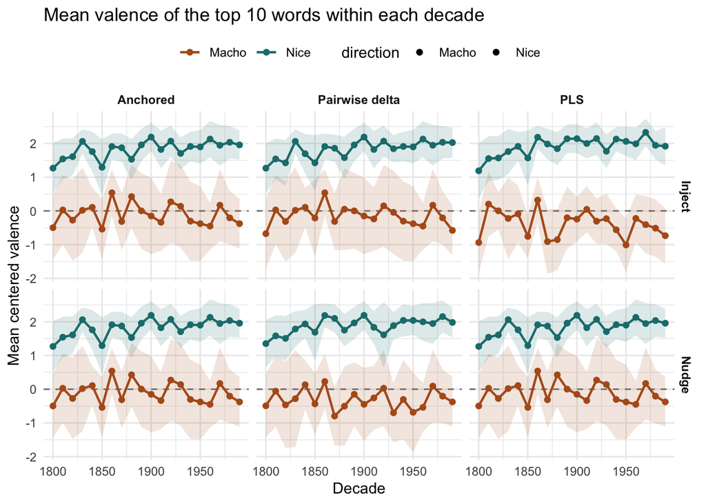

```r
  warriner_valence_plot
```

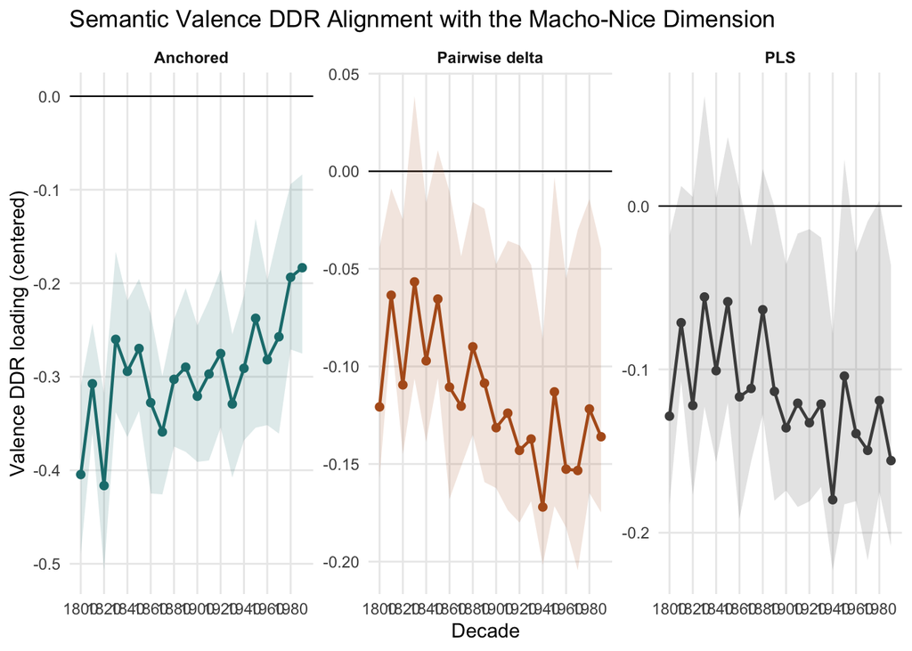

```r
  valence_ddr_time_plot
```

## 4.3 Q4 -Attractiveness

This section intentionally keeps **both** Attractiveness workflows in the same document.

The older workflow, which came from `main`, asks two separate questions for each decade: “How close is Attractiveness to Macho?” and “How close is Attractiveness to Nice?” The newer workflow, from `anlysis-after-opt`, asks a single contrast question: “Is Attractiveness closer to Macho or to Nice?”

### 4.3.1 Word list

- Nudge version: uses only the attractiveness descriptors.
- Inject version: includes the attractiveness descriptors plus the male anchor words, ensuring a stronger masculine reference frame in the embedding space.

This parallels the earlier Macho/Nice pipeline for consistency.

```r
attractiveness_words <- c(
  "attractive",
  "handsome",
  "sexy",
  "alluring",
  "charming",
  "appealing"
)

attractiveness_words_injected <- attractiveness_words |>
  c(male_anchors)
```

For each decade, I build an Attractiveness vector using the same two strategies used above for Macho and Nice:

**Inject condition**

1. Retrieve the embeddings of all attractiveness words + male anchors.
2. Compute their **average embedding**, yielding the *Attractiveness Injected DDR* for that decade.

**Nudge condition**

1. Retrieve the embeddings of the attractiveness adjectives.
2. Average them to obtain the raw *Attractiveness Nudge DDR*.
3. Apply the **`masculinity_nudge()`** transformation to align the DDR with the nudge paradigm used for the Macho/Nice DDRs.

```r
Attractiveness_DDR_injected_by_decade <- vector("list", length(ENGall_model))
Attractiveness_DDR_nudge_by_decade <- vector("list", length(ENGall_model))

for (i in seq_along(ENGall_model)) {
  embeddings <- ENGall_model[[i]]
  embeddings <- embeddings[magnitude(embeddings) != 0, ]

  Attractiveness_DDR_injected_by_decade[[i]] <- build_ddr(
    embeddings = embeddings,
    words = attractiveness_words_injected
  )

  Attractiveness_DDR_nudge_by_decade[[i]] <- build_ddr(
    embeddings = embeddings,
    words = attractiveness_words
  ) |>
    masculinity_nudge(E = embeddings)
}

names(Attractiveness_DDR_injected_by_decade) <- decades
names(Attractiveness_DDR_nudge_by_decade) <- decades
```

### 4.3.2 DDR analysis

now after we constructed our attractiveness DDR, lets inspect the results of the attractiveness DDR in terms of its loading on the macho/nice axis - across the 3 approach, How does the metric of interest change across years.

```r
# raw computation:
cosine_scores_attractives_decades<- vector("list", length(ENGall_model))
pls_scores_attractives_decades<- vector("list", length(ENGall_model))
anchor_scores_attractives_decades<- vector("list", length(ENGall_model))
# cleaned versions:
cosine_clean_attractives_decades<- vector("list", length(ENGall_model))
pls_clean_attractives_decades<- vector("list", length(ENGall_model))
anchor_clean_attractives_decades<- vector("list", length(ENGall_model))


for (i in seq_along(ENGall_model)) {
  # Method 1: Pairwise Deltas
  cosine_scores_attractives_decades[[i]] <- rbind(
    macho_nudge_embds = Macho_DDR_nudge_by_decade[[i]],
    nice_nudge_embds  = Nice_DDR_nudge_by_decade[[i]],
    macho_inject_embds = Macho_DDR_injected_by_decade[[i]],
    nice_inject_embds  = Nice_DDR_injected_by_decade[[i]])|>
    get_sims(
      list(
        "attractiveness_cos_nudge" = Attractiveness_DDR_nudge_by_decade[[i]],
        "attractiveness_cos_inject" = Attractiveness_DDR_injected_by_decade[[i]]
      ),
      method = "cosine"
    ) |>
    as.data.frame() |>
    mutate(
      construct = c(
        "macho_nudge_embds",
        "nice_nudge_embds",
        "macho_inject_embds",
        "nice_inject_embds"
      ),
      .before = 1
    )|>

    # notice that the data strcuture is less complaing with inject x nudge cells intersect.
    mutate(
      construct_type = case_when(
        str_detect(construct, "nice")  ~ "nice",
        str_detect(construct, "macho") ~ "macho"

      ),
      approach = case_when(
        str_detect(construct, "nudge")  ~ "nudge",
        str_detect(construct, "inject") ~ "inject"
      ),
      cos_sim_attractive = case_when(
        approach == "nudge"  ~ attractiveness_cos_nudge,
        approach == "inject" ~ attractiveness_cos_inject
      )
    ) |>
    select(approach, construct_type, cos_sim_attractive) |>
    pivot_wider(
      names_from = construct_type,
      values_from = cos_sim_attractive
    ) |>
    mutate(
      attractive_delta = macho - nice
    )
  # Method 2: Anchored Macho-Nice Axis
  anchor_scores_attractives_decades[[i]] <- rbind(
    Attractivness_inject= Attractiveness_DDR_injected_by_decade[[i]],
    Attractivness_nudge_ddr = Attractiveness_DDR_nudge_by_decade[[i]]
  ) |>
    get_sims(
      list(
        "macho_vs_nice_inject" = list(
          pos = Macho_DDR_injected_by_decade[[i]],
          neg = Nice_DDR_injected_by_decade[[i]]
        ),
        "macho_vs_nice_nudge" = list(
          pos = Macho_DDR_nudge_by_decade[[i]],
          neg = Nice_DDR_nudge_by_decade[[i]]
        )
      ),
      method = "anchored"
    ) |>
    as.data.frame() |>
    mutate(
      construct = c(
        "Attractivness_inject",
        "Attractivness_nudge"
      ),
      .before = 1
    )

  # Method 3: PLS Axis

  #reusing the object already created in the previous sections (namely, r DDRs,warning=FALSE)

  pls_scores_attractives_decades[[i]] <- rbind(
    Attractivness_nudge_ddr = Attractiveness_DDR_nudge_by_decade[[i]],
    Attractivness_inject= Attractiveness_DDR_injected_by_decade[[i]]
  ) |>
    get_sims(
      list(
        "pls_nudge"  = pls_nudge_axis_by_decade[[i]]
      ),
      method = "cosine"
    ) |>
    as.data.frame() |>
    mutate(
      construct = c(
        "Attractivness_nudge_ddr"
      ),
      .before = 1
   )



  # Organizing data structure:

  #  each iteration I want two values: delta cosimilarity for each appeaoch
  cosine_clean_attractives_decades[[i]]<- cosine_scores_attractives_decades[[i]] |>
    mutate(
      nudge_delta =cosine_scores_attractives_decades[[i]] |>
        filter(approach == "nudge") |>
        pull(attractive_delta),
      inject_delta =cosine_scores_attractives_decades[[i]] |>
        filter(approach == "inject") |>
        pull(attractive_delta)
    ) |>
    select(nudge_delta, inject_delta) |>
    slice(1)

  anchor_clean_attractives_decades[[i]]<- anchor_scores_attractives_decades[[i]]|>
    mutate(
      anchor_inject =anchor_scores_attractives_decades[[i]] |>
        filter(construct == "Attractivness_inject") |>
        pull(macho_vs_nice_inject),
      anchor_nudge =anchor_scores_attractives_decades[[i]] |>
        filter(construct == "Attractivness_nudge") |>
        pull(macho_vs_nice_nudge)
    ) |>
    select(anchor_nudge, anchor_inject) |>
    slice(1) |>

   # Interpectatioin transformation: the anchored method is a similarity measure, so the values are between 0 and 1. I want to transform them to be between -1 and 1, so that they are comparable to the other methods.
  mutate(
    anchor_nudge  = 2 * anchor_nudge - 1,
    anchor_inject = 2 * anchor_inject - 1
  )

  pls_clean_attractives_decades[[i]] <- pls_scores_attractives_decades[[i]] |>
    mutate(
      pls_nudge =pls_scores_attractives_decades[[i]] |>
        filter(construct == "Attractivness_nudge_ddr") |>
        pull(pls_nudge)
    ) |>
    select(pls_nudge) |>
    slice(1)
}
   # summarise and join the cleaned listed with decade as an identifier
cosine_clean_df <- bind_rows(
  cosine_clean_attractives_decades,
  .id = "decade_id"
)|>
  mutate(
    decade = decades[as.integer(decade_id)],
    .before=1
  )

anchor_clean_df <- bind_rows(
  anchor_clean_attractives_decades,
  .id = "decade_id"
)

pls_clean_df <- bind_rows(
  pls_clean_attractives_decades,
  .id = "decade_id"
)

attractiveness_decade_summary <- cosine_clean_df |>
  left_join(anchor_clean_df, by = "decade_id") |>
  left_join(pls_clean_df, by = "decade_id")
```

```r
attractiveness_background_adjusted <- attractiveness_decade_summary |>
  select(
    decade,
    nudge_delta,
    inject_delta,
    anchor_nudge,
    anchor_inject,
    pls_nudge
  ) |>
  pivot_longer(
    cols = -decade,
    names_to = "score_type",
    values_to = "absolute_score"
  ) |>
  mutate(
    method = case_when(
      str_detect(score_type, "delta")  ~ "Pairwise delta",
      str_detect(score_type, "anchor") ~ "Anchored",
      str_detect(score_type, "pls")    ~ "PLS"
    ),
    approach = case_when(
      str_detect(score_type, "nudge")  ~ "Nudge",
      str_detect(score_type, "inject") ~ "Inject"
    )
  ) |>
  left_join(
    rq1_data |>
      select(decade, method, approach, baseline_mean),
    by = c("decade", "method", "approach")
  ) |>
  mutate(
    # Target-specific position relative to the lexicon-wide
    # background in the same decade.
    background_adjusted_score =
      absolute_score - baseline_mean,

    absolute_direction = case_when(
      absolute_score > 0 ~ "Macho",
      absolute_score < 0 ~ "Nice",
      TRUE ~ "Neutral"
    ),

    background_relative_direction = case_when(
      background_adjusted_score > 0 ~ "More Macho than vocabulary",
      background_adjusted_score < 0 ~ "More Nice than vocabulary",
      TRUE ~ "Equal to vocabulary"
    ),

    decade_index = (decade - min(decade)) / 10
  ) |>
  arrange(method, approach, decade)



attractiveness_background_adjusted
```

```
# A tibble: 100 × 10
   decade score_type    absolute_score method   approach baseline_mean
    <dbl> <chr>                  <dbl> <chr>    <chr>            <dbl>
 1   1800 anchor_inject       -0.133   Anchored Inject        -0.0929
 2   1810 anchor_inject        0.0545  Anchored Inject        -0.0561
 3   1820 anchor_inject       -0.0589  Anchored Inject        -0.128
 4   1830 anchor_inject       -0.0605  Anchored Inject        -0.00466
 5   1840 anchor_inject       -0.151   Anchored Inject        -0.0288
 6   1850 anchor_inject        0.00735 Anchored Inject        -0.00896
 7   1860 anchor_inject       -0.0838  Anchored Inject        -0.0104
 8   1870 anchor_inject       -0.00704 Anchored Inject        -0.0319
 9   1880 anchor_inject       -0.145   Anchored Inject        -0.0178
10   1890 anchor_inject        0.00730 Anchored Inject         0.0475
# ℹ 90 more rows
# ℹ 4 more variables: background_adjusted_score <dbl>,
#   absolute_direction <chr>, background_relative_direction <chr>,
#   decade_index <dbl>
```

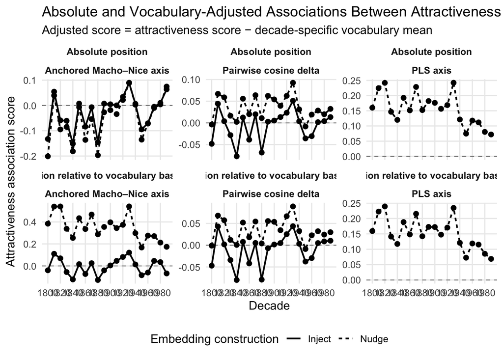

```r
attractiveness_plot_df <- attractiveness_background_adjusted |>
  select(
    decade,
    method,
    approach,
    absolute_score,
    background_adjusted_score
  ) |>
  pivot_longer(
    cols = c(
      absolute_score,
      background_adjusted_score
    ),
    names_to = "score_basis",
    values_to = "score"
  ) |>
  mutate(
    axis_method = recode(
      method,
      "Pairwise delta" = "Pairwise cosine delta",
      "Anchored"       = "Anchored Macho–Nice axis",
      "PLS"            = "PLS axis"
    ),
    score_basis = recode(
      score_basis,
      "absolute_score" =
        "Absolute position",
      "background_adjusted_score" =
        "Position relative to vocabulary baseline"
    )
  )

ggplot(
  attractiveness_plot_df,
  aes(
    x = decade,
    y = score,
    linetype = approach,
    group = interaction(
      axis_method,
      approach,
      score_basis
    )
  )
) +
  geom_hline(
    yintercept = 0,
    linewidth = 0.4,
    linetype = "dashed",
    color = "grey50"
  ) +
  geom_line(linewidth = 0.8) +
  geom_point(size = 2) +
  facet_wrap(
    vars(score_basis, axis_method),
    ncol = 3,
    scales = "free_y"
  ) +
  scale_x_continuous(
    breaks = seq(1800, 1990, by = 20)
  ) +
  labs(
    x = "Decade",
    y = "Attractiveness association score",
    linetype = "Embedding construction",
    title = paste(
      "Absolute and Vocabulary-Adjusted Associations Between",
      "Attractiveness and the Macho–Nice Dimension"
    ),
    subtitle = paste(
      "Adjusted score = attractiveness score −",
      "decade-specific vocabulary mean"
    )
  ) +
  theme_minimal(base_size = 12) +
  theme(
    legend.position = "bottom",
    panel.grid.minor = element_blank(),
    strip.text = element_text(face = "bold")
  )
```

**NoteWhat now**

Stuff to need to take into consideration to thoroughly continue the analysis

method: 1- Currently the masculinity nudge is set to w=1, meaning that the the nudge is very very storng toward the masculine side. try maybe something more sable. * should inspect show what happening when varying w

2- the Attractiveness DDR also is constructed using the same “masculine context” embedding both inject and nudge method (which is also set to w=1!) I suspect that the results showed in @warriner that almost all the words loaded greatly more to the macho side of the axis (as shown in *macho_vs_nice* columns) is due to that the attractiveness is also pushed too strongly to the masculinity side.

- should inspect what happend when attractiveness not in the “masculine side” non-inject and non-nudged

future:

3 - Attractiveness as a sexual properties- changing the word bank 4- euclidean distance between the macho and nice guy construct as a support of the existance of a split. * since only relative distance is possible for comparison across decades, a method is needed to examing the change (distance ) between the constructs. I’m thinking of taking the delta distance of every word from our macho/nice constructs, compute a delta and average across ALL the words and see if this average delta changes across time/

5- what other axaminations would indicate such “stereotype-Split”?

## 4.4 Q5 - Relationship type

It does seems that in the literature the only sliant and psychology related findings was that although macho men tend to be percived as more attractive and sexual the appeal prevail only when the relationship type is od casual and non long lasting. When the latter is true, its seems that women are more drawn and prefer the characteristics of the nice guy better than the macho men.

another articles talks about the prefrance of a women in terms of sxual activity and the place in which sexuality takesin their life - *Edward S. Herold & Robin R. Milhausen (1999) Dating preferences of university women: An analysis of the nice guy stereotype, Journal of Sex & Marital Therapy, 25:4, 333-343, DOI: 10.1080/00926239908404010*

To probe that idea directly, I define two new target DDRs. The first is a **long-committed relationship** construct, built from words that emphasize stability, devotion, and pair-bonding. The second is a **short-casual sexual relationship** construct, built from words that emphasize casualness, desire, and sexual gratification.

Because these constructs describe *relationship types* rather than *men themselves*, I keep them as **raw semantic targets**. In other words, I do **not** inject male anchors into the relationship DDRs. Instead, I project the two relationship DDRs onto the **nudge-based** Macho-Nice dimension and ask which relationship type falls closer to the Nice side and which falls closer to the Macho side.

```r
long_committed_relationship_words <- c(
  "committed",
  "faithful",
  "loyal",
  "devoted",
  "marriage",
  "married",
  "partner",
  "romantic",
  "enduring",
  "stable"
)

casual_sexual_relationship_words <- c(
  "casual",
  "sexual",
  "sensual",
  "lust",
  "desire",
  "passionate",
  "promiscuous",
  "physical",
  "pleasure",
  "tempting"
)

relationship_word_coverage <- map_dfr(seq_along(ENGall_model), function(i) {
  embeddings <- ENGall_model[[i]]
  embeddings <- embeddings[magnitude(embeddings) != 0, ]

  tibble(
    decade = decades[i],
    long_committed_available = sum(
      long_committed_relationship_words %in% rownames(embeddings)
    ),
    casual_sexual_available = sum(
      casual_sexual_relationship_words %in% rownames(embeddings)
    )
  )
})

kable(
  relationship_word_coverage,
  caption = "Available words per decade for the relationship-type DDRs"
)
```

Available words per decade for the relationship-type DDRs

| decade | long_committed_available | casual_sexual_available |
| --- | --- | --- |
| 1800 | 10 | 9 |
| 1810 | 10 | 9 |
| 1820 | 10 | 10 |
| 1830 | 10 | 10 |
| 1840 | 10 | 10 |
| 1850 | 10 | 10 |
| 1860 | 10 | 10 |
| 1870 | 10 | 10 |
| 1880 | 10 | 10 |
| 1890 | 10 | 10 |
| 1900 | 10 | 10 |
| 1910 | 10 | 10 |
| 1920 | 10 | 10 |
| 1930 | 10 | 10 |
| 1940 | 10 | 10 |
| 1950 | 10 | 10 |
| 1960 | 10 | 10 |
| 1970 | 10 | 10 |
| 1980 | 10 | 10 |
| 1990 | 10 | 10 |

```r
LongCommitted_DDR_by_decade <- vector("list", length(ENGall_model))
CasualSexual_DDR_by_decade <- vector("list", length(ENGall_model))

for (i in seq_along(ENGall_model)) {
  embeddings <- ENGall_model[[i]]
  embeddings <- embeddings[magnitude(embeddings) != 0, ]

  LongCommitted_DDR_by_decade[[i]] <- build_ddr(
    embeddings = embeddings,
    words = long_committed_relationship_words
  )

  CasualSexual_DDR_by_decade[[i]] <- build_ddr(
    embeddings = embeddings,
    words = casual_sexual_relationship_words
  )
}

names(LongCommitted_DDR_by_decade) <- decades
names(CasualSexual_DDR_by_decade) <- decades
```

### 4.4.1 Relationship-type analysis

```r
relationship_scores_decades <- vector("list", length(ENGall_model))

for (i in seq_along(ENGall_model)) {
  relationship_targets <- rbind(
    LongCommitted = LongCommitted_DDR_by_decade[[i]],
    CasualSexual = CasualSexual_DDR_by_decade[[i]]
  )

  delta_scores <- relationship_targets |>
    get_sims(
      list(
        macho = Macho_DDR_nudge_by_decade[[i]],
        nice = Nice_DDR_nudge_by_decade[[i]]
      ),
      method = "cosine"
    ) |>
    as.data.frame()

  anchor_scores <- relationship_targets |>
    get_sims(
      list(
        anchor = list(
          pos = Macho_DDR_nudge_by_decade[[i]],
          neg = Nice_DDR_nudge_by_decade[[i]]
        )
      ),
      method = "anchored"
    ) |>
    as.data.frame()

  pls_scores <- relationship_targets |>
    get_sims(
      list(
        pls = pls_nudge_axis_by_decade[[i]]
      ),
      method = "cosine"
    ) |>
    as.data.frame()

  relationship_scores_decades[[i]] <- tibble(
    construct = c("Long committed", "Casual sexual"),
    decade = decades[i],
    pairwise_delta = delta_scores$macho - delta_scores$nice,
    anchored_axis = anchor_scores$anchor - 0.5,
    pls_axis = pls_scores$pls
  )
}

relationship_plot_df <- bind_rows(relationship_scores_decades) |>
  pivot_longer(
    cols = c(pairwise_delta, anchored_axis, pls_axis),
    names_to = "axis_method",
    values_to = "score"
) |>
  mutate(
    axis_method = case_when(
      axis_method == "pairwise_delta" ~ "Pairwise cosine delta",
      axis_method == "anchored_axis" ~ "Anchored macho-nice axis",
      axis_method == "pls_axis" ~ "PLS axis"
    )
  )

relationship_summary_table <- relationship_plot_df |>
  group_by(axis_method, construct) |>
  summarise(
    mean_score = mean(score, na.rm = TRUE),
    min_score = min(score, na.rm = TRUE),
    max_score = max(score, na.rm = TRUE),
    .groups = "drop"
  )

kable(
  relationship_summary_table,
  digits = 3,
  caption = "Average relationship-type loading on the Macho-Nice dimension across methods"
)
```

Average relationship-type loading on the Macho-Nice dimension across methods

| axis_method | construct | mean_score | min_score | max_score |
| --- | --- | --- | --- | --- |
| Anchored macho-nice axis | Casual sexual | -0.278 | -0.376 | -0.186 |
| Anchored macho-nice axis | Long committed | -0.277 | -0.432 | -0.098 |
| PLS axis | Casual sexual | -0.100 | -0.221 | 0.008 |
| PLS axis | Long committed | -0.112 | -0.207 | -0.049 |
| Pairwise cosine delta | Casual sexual | -0.089 | -0.194 | 0.004 |
| Pairwise cosine delta | Long committed | -0.092 | -0.155 | -0.048 |

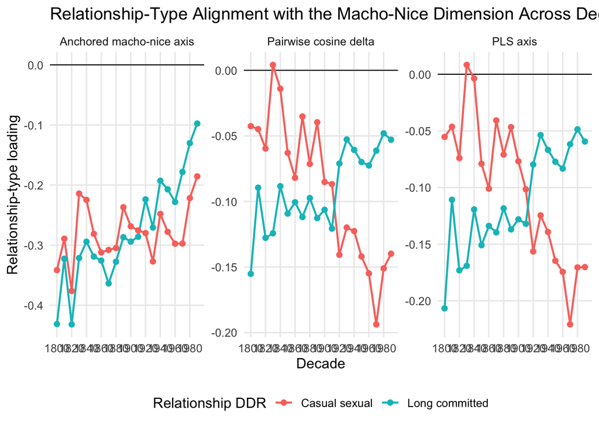

```r
ggplot(
  relationship_plot_df,
  aes(
    x = decade,
    y = score,
    color = construct,
    group = construct
  )
) +
  geom_hline(yintercept = 0, linewidth = 0.4) +
  geom_line(linewidth = 0.8) +
  geom_point(size = 1.8) +
  facet_wrap(~ axis_method, scales = "free_y") +
  scale_x_continuous(
    breaks = seq(1800, 1990, by = 20)
  ) +
  labs(
    x = "Decade",
    y = "Relationship-type loading",
    color = "Relationship DDR",
    title = "Relationship-Type Alignment with the Macho-Nice Dimension Across Decades"
  ) +
  theme_minimal(base_size = 12) +
  theme(
    legend.position = "bottom",
    panel.grid.minor = element_blank()
  )
```

Across the three scoring families, the **long-committed relationship** DDR is expected to sit closer to the **Nice** pole, whereas the **casual-sexual relationship** DDR should sit relatively closer to the **Macho** pole. In practice, the key question is not whether the casual-sexual DDR always becomes fully Macho-coded, but whether it is **consistently less Nice-coded** than the long-committed DDR. If that pattern holds, it would mirror the literature’s claim that the Macho stereotype is more compatible with short-term sexual appeal, whereas the Nice stereotype is more compatible with long-term commitment.

## 4.5 Q6 - Split Growth Across Decades

### 4.5.1 Choosing the split measures

The historical embedding spaces are trained separately, so I do not compare a vector from one decade directly with a vector from another decade. Instead, I compute each Macho–Nice relationship **within its own decade** and then model the resulting scalar time series. Within-decade cosine and Euclidean relationships are unchanged by an arbitrary rotation of the coordinate axes; direct cross-decade vector displacement would still require alignment.

The five reported quantities do not provide five independent tests of the same idea. They have different roles:

1. **Prototype cosine distance is the primary outcome.** It measures directional separation between the Macho and Nice DDRs, is unaffected by vector length, and is therefore the clearest measure of whether the two prototypes become more or less distinct.
2. **Normalized Euclidean distance is an equivalent geometric display.** For unit-length vectors it is determined exactly by cosine distance, $d_{E}=\sqrt{2d_{cos}}$. I report it descriptively because distance is intuitive, but I do not model it as independent confirmation.
3. **Raw Euclidean distance is a magnitude-sensitivity outcome.** It changes with both direction and vector length. It is retained to show whether conclusions depend on DDR magnitude, but it is not treated as primary evidence of semantic separation.
4. **Mean absolute delta is a lexicon-wide polarization outcome.** It asks how strongly the average available word is pulled toward either pole, regardless of direction.
5. **The SD of delta is a lexicon-wide dispersion outcome.** It asks how widely word positions are spread across the Macho–Nice contrast.

The prototype measures and lexicon-wide measures answer complementary questions: the former concern the distance between the two constructed prototypes, whereas the latter concern how the surrounding vocabulary is distributed relative to them. The lexicon-wide measures are conditional on the words available in each decade, and all measures are conditional on the construct seed words available in that decade. Availability weighting and the early-decade robustness analysis reduce this concern but do not make changing vocabularies identical; a fixed-seed and fixed-vocabulary sensitivity analysis should therefore accompany any strong historical claim.

### 4.5.2 Checking for tracking before trend modeling

Before fitting any formal time-trend model, I first check whether the decade series shows signs of **tracking**, meaning that adjacent decades carry similar residual error. This matters because a simple linear model assumes that once the overall trend is fitted, the remaining errors are independent. In diachronic semantic data that assumption is often unrealistic: the meaning of masculinity in 1900 is not generated from scratch, but evolves gradually from 1890 and 1910.

If residuals track each other over time, then an ordinary linear model becomes overconfident. In practical terms, that means:

- standard errors can be too small;
- p-values can be too optimistic;
- confidence intervals can be too narrow.

To run that diagnostic, I first calculate the split metrics. They belong to two substantive families:

1. **prototype distance**: how far apart the Macho and Nice Guy DDRs are in a given decade;
2. **lexicon-wide polarization**: how strongly the whole decade lexicon is pulled toward one pole versus the other.

Normalization matters because a DDR is an **average vector**, and average vectors are **not** unit length. In cosine-based measures this is not a problem, because cosine is scale-invariant: normalizing a vector does **not** change its cosine relationship to another vector. In raw Euclidean distance, however, vector length matters. A larger raw distance can reflect either:

1. a stronger directional split between Macho and Nice;
2. or simply longer DDR vectors in that decade.

For that reason, raw Euclidean distance is presented as a sensitivity check, while cosine distance is the primary directional measure. Normalized Euclidean distance remains in the descriptive display only to make the geometry intuitive; because it is a deterministic transformation of cosine distance, it is not entered as a separate inferential outcome.

```r
split_metrics_decades <- vector("list", length(ENGall_model))

for (i in seq_along(ENGall_model)) {
  embeddings <- ENGall_model[[i]]
  embeddings <- embeddings[magnitude(embeddings) != 0, ]

  macho_ddr_raw <- as.numeric(Macho_DDR_nudge_by_decade[[i]])
  nice_ddr_raw <- as.numeric(Nice_DDR_nudge_by_decade[[i]])

  macho_ddr_norm <- normalize(macho_ddr_raw)
  nice_ddr_norm <- normalize(nice_ddr_raw)

  delta_scores <- embeddings |>
    get_sims(
      list(
        macho = macho_ddr_norm,
        nice = nice_ddr_norm
      ),
      method = "cosine"
    ) |>
    as.data.frame() |>
    transmute(delta = macho - nice)

  split_metrics_decades[[i]] <- tibble(
    decade = decades[i],
    macho_norm = magnitude(macho_ddr_raw),
    nice_norm = magnitude(nice_ddr_raw),
    cosine_similarity = cos_sim(macho_ddr_raw, nice_ddr_raw),
    cosine_distance = 1 - cos_sim(macho_ddr_raw, nice_ddr_raw),
    raw_euclidean_distance = euc_dist(macho_ddr_raw, nice_ddr_raw),
    normalized_euclidean_distance = euc_dist(macho_ddr_norm, nice_ddr_norm),
    mean_abs_delta = mean(abs(delta_scores$delta), na.rm = TRUE),
    sd_delta = sd(delta_scores$delta, na.rm = TRUE)
  )
}

split_metrics_df <- bind_rows(split_metrics_decades)

split_metric_spec <- tribble(
  ~metric, ~metric_label, ~analysis_role, ~purpose, ~include_in_models,
  "cosine_distance",
  "Prototype cosine distance",
  "Primary prototype outcome",
  "Directional separation of the Macho and Nice prototypes; unaffected by DDR length.",
  TRUE,
  "normalized_euclidean_distance",
  "Prototype Euclidean distance (normalized)",
  "Equivalent geometric display",
  "An intuitive distance display that is mathematically determined by cosine distance; not independent evidence.",
  FALSE,
  "raw_euclidean_distance",
  "Prototype Euclidean distance (raw)",
  "Magnitude-sensitivity outcome",
  "Checks whether conclusions change when DDR vector length contributes to prototype separation.",
  TRUE,
  "mean_abs_delta",
  "Mean absolute delta across lexicon",
  "Lexicon-wide polarization outcome",
  "Average strength with which available words lean toward either pole, regardless of direction.",
  TRUE,
  "sd_delta",
  "SD of delta across lexicon",
  "Lexicon-wide dispersion outcome",
  "Spread of word positions across the Macho--Nice contrast.",
  TRUE
)

split_diagnostic_metrics <- split_metric_spec$metric

split_modeled_metrics <- split_metric_spec |>
  filter(include_in_models) |>
  pull(metric)

kable(
  split_metric_spec |>
    transmute(
      `Analysis role` = analysis_role,
      Measure = metric_label,
      `Why it is included` = purpose,
      `Formally modeled` = if_else(include_in_models, "Yes", "No--descriptive equivalent")
    ),
  caption = "Purpose and inferential role of each Macho--Nice split measure",
  align = c("l", "l", "l", "l")
)
```

Purpose and inferential role of each Macho–Nice split measure

| Analysis role | Measure | Why it is included | Formally modeled |
| --- | --- | --- | --- |
| Primary prototype outcome | Prototype cosine distance | Directional separation of the Macho and Nice prototypes; unaffected by DDR length. | Yes |
| Equivalent geometric display | Prototype Euclidean distance (normalized) | An intuitive distance display that is mathematically determined by cosine distance; not independent evidence. | No–descriptive equivalent |
| Magnitude-sensitivity outcome | Prototype Euclidean distance (raw) | Checks whether conclusions change when DDR vector length contributes to prototype separation. | Yes |
| Lexicon-wide polarization outcome | Mean absolute delta across lexicon | Average strength with which available words lean toward either pole, regardless of direction. | Yes |
| Lexicon-wide dispersion outcome | SD of delta across lexicon | Spread of word positions across the Macho–Nice contrast. | Yes |

```r
kable(
  split_metrics_df |>
    transmute(
      Decade = decade,
      `Primary: cosine distance` = cosine_distance,
      `Equivalent display: normalized Euclidean` = normalized_euclidean_distance,
      `Sensitivity: raw Euclidean` = raw_euclidean_distance,
      `Lexicon mean: absolute delta` = mean_abs_delta,
      `Lexicon spread: SD delta` = sd_delta
    ),
  digits = 3,
  caption = "Primary, sensitivity, and complementary Macho--Nice split measures by decade"
)
```

Primary, sensitivity, and complementary Macho–Nice split measures by decade

| Decade | Primary: cosine distance | Equivalent display: normalized Euclidean | Sensitivity: raw Euclidean | Lexicon mean: absolute delta | Lexicon spread: SD delta |
| --- | --- | --- | --- | --- | --- |
| 1800 | 0.279 | 0.748 | 0.599 | 0.065 | 0.081 |
| 1810 | 0.272 | 0.737 | 0.619 | 0.048 | 0.060 |
| 1820 | 0.279 | 0.747 | 0.603 | 0.046 | 0.058 |
| 1830 | 0.305 | 0.782 | 0.637 | 0.048 | 0.060 |
| 1840 | 0.337 | 0.821 | 0.648 | 0.050 | 0.063 |
| 1850 | 0.310 | 0.788 | 0.648 | 0.047 | 0.059 |
| 1860 | 0.313 | 0.792 | 0.632 | 0.048 | 0.061 |
| 1870 | 0.349 | 0.836 | 0.668 | 0.050 | 0.063 |
| 1880 | 0.347 | 0.833 | 0.675 | 0.051 | 0.065 |
| 1890 | 0.337 | 0.821 | 0.659 | 0.050 | 0.063 |
| 1900 | 0.333 | 0.816 | 0.633 | 0.048 | 0.061 |
| 1910 | 0.338 | 0.822 | 0.646 | 0.047 | 0.059 |
| 1920 | 0.364 | 0.854 | 0.661 | 0.049 | 0.062 |
| 1930 | 0.329 | 0.811 | 0.666 | 0.044 | 0.057 |
| 1940 | 0.325 | 0.806 | 0.649 | 0.046 | 0.059 |
| 1950 | 0.321 | 0.801 | 0.637 | 0.044 | 0.056 |
| 1960 | 0.329 | 0.811 | 0.666 | 0.044 | 0.056 |
| 1970 | 0.338 | 0.822 | 0.645 | 0.042 | 0.054 |
| 1980 | 0.341 | 0.826 | 0.651 | 0.041 | 0.053 |
| 1990 | 0.314 | 0.792 | 0.636 | 0.038 | 0.049 |

To diagnose tracking, I intentionally fit a **simple ordinary least squares (OLS)** line to each split metric. This is *not* the final model. It is a diagnostic baseline whose residuals let us ask a simple question: after removing a basic linear time trend, do adjacent decades still move together?

I first prepare the time index and also join the decade-level embedding availability information. The availability values are not needed for the residual diagnostic itself, but they will be used in the weighted models that follow.

```r
split_model_df <- split_metrics_df |>
  left_join(
    avwords_n_decade_df |>
      select(decade, n_avwords, prop_avail),
    by = "decade"
  ) |>
  mutate(
    time_decades = (decade - min(decade)) / 10,
    decade_index = row_number()
  )
```

In the next chunk, I extract two diagnostic quantities from the simple OLS fits:

- the **raw residuals**, which show whether adjacent decades tend to stay above or below the fitted line together;
- the **studentized residuals**, which scale each residual by its estimated uncertainty. Values larger than about `|3|` are often treated as unusually extreme.

If residuals show long runs of the same sign, or if the lag-1 residual correlation is high, that is evidence of tracking and therefore evidence that a simple independent-errors model is not appropriate.

```r
split_tracking_diagnostics_df <- split_diagnostic_metrics |>
  map_dfr(function(metric) {
    fit <- lm(reformulate("time_decades", response = metric), data = split_model_df)

    tibble(
      decade = split_model_df$decade,
      metric = metric,
      fitted = fitted(fit),
      residual = resid(fit),
      studentized = rstudent(fit)
    )
  }) |>
  left_join(
    split_metric_spec |>
      select(metric, metric_label, analysis_role),
    by = "metric"
  )
```

The next table summarizes the most important diagnostic signals. The **lag-1 residual correlation** tells us how similar each residual is to the next decade’s residual. Values clearly above zero indicate temporal carryover. The **maximum absolute studentized residual** and the number of residuals larger than `|3|` help identify whether isolated extreme decades are also contributing to the problem.

```r
split_tracking_summary_table <- split_tracking_diagnostics_df |>
  group_by(analysis_role, metric_label) |>
  summarise(
    lag1_residual_correlation = cor(residual[-n()], residual[-1]),
    max_abs_studentized = max(abs(studentized), na.rm = TRUE),
    n_abs_studentized_gt3 = sum(abs(studentized) > 3, na.rm = TRUE),
    .groups = "drop"
  )

kable(
  split_tracking_summary_table |>
    transmute(
      `Analysis role` = analysis_role,
      Measure = metric_label,
      `Lag-1 residual correlation` = lag1_residual_correlation,
      `Largest |studentized residual|` = max_abs_studentized,
      `Number with |residual| > 3` = n_abs_studentized_gt3
    ),
  digits = 3,
  caption = "Residual diagnostics for detecting tracking in the decade series"
)
```

Residual diagnostics for detecting tracking in the decade series

| Analysis role | Measure | Lag-1 residual correlation | Largest \|studentized residual\| | Number with \|residual\| > 3 |
| --- | --- | --- | --- | --- |
| Equivalent geometric display | Prototype Euclidean distance (normalized) | 0.530 | 1.800 | 0 |
| Lexicon-wide dispersion outcome | SD of delta across lexicon | 0.119 | 5.394 | 1 |
| Lexicon-wide polarization outcome | Mean absolute delta across lexicon | 0.121 | 5.314 | 1 |
| Magnitude-sensitivity outcome | Prototype Euclidean distance (raw) | 0.355 | 2.068 | 0 |
| Primary prototype outcome | Prototype cosine distance | 0.515 | 1.881 | 0 |

#### 4.5.2.1 Plot

I now plot the raw residuals against time. If the residuals are independent, these panels should look patternless. If nearby decades cluster together above or below zero, that is visual evidence of tracking.

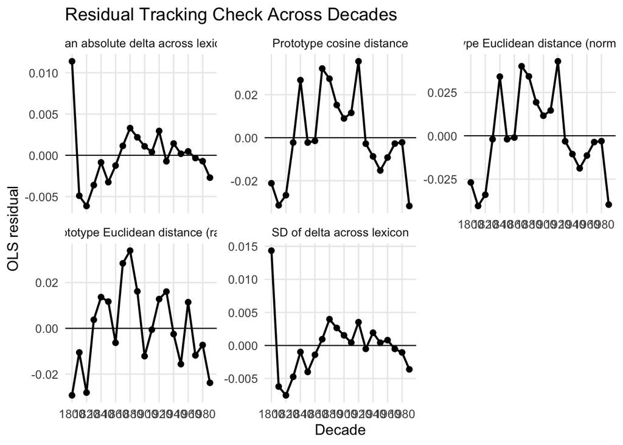

```r
ggplot(
  split_tracking_diagnostics_df,
  aes(x = decade, y = residual)
) +
  geom_hline(yintercept = 0, linewidth = 0.4) +
  geom_line(linewidth = 0.8) +
  geom_point(size = 1.8) +
  facet_wrap(~ metric_label, scales = "free_y") +
  scale_x_continuous(
    breaks = seq(1800, 1990, by = 20)
  ) +
  labs(
    x = "Decade",
    y = "OLS residual",
    title = "Residual Tracking Check Across Decades"
  ) +
  theme_minimal(base_size = 12) +
  theme(
    panel.grid.minor = element_blank()
  )
```